# 20200603_rnaseq-tissue-data-assembly_steep.R

Alec

2020-07-09

```r
'---
#' # title: 'PASS1A Rat Tissue: -- Data Assembly'
```

```
## [1] "---\n#"
```

author: ‘Alec Steep & Jiayu Zhang’ date: ‘20200604’ output: html_document: code_folding: hide toc: true highlight: zenburn

## Goals of Analysis:

- Assembly Data

## Setup the Environment

```r
################################################################################
##### Resources and Dependencies ###############################################
################################################################################

# Set the working directory
WD <- '/Volumes/Frishman_4TB/motrpac/20200309_rna-seq_steep'
#setwd(WD)

# Load the dependencies
#source('https://bioconductor.org/biocLite.R')
#BiocManager::install('ImpulseDE2')
#install.packages('tidyverse')

# Load dependencies
pacs...man <- c('tidyverse','GenomicRanges', 'DESeq2','devtools','rafalib','GO.db','vsn','hexbin','ggplot2', 'GenomicFeatures','Biostrings','BSgenome','AnnotationHub','plyr','dplyr', 'org.Rn.eg.db','pheatmap','sva','formula.tools','pathview','biomaRt', 'PROPER','SeqGSEA','purrr','BioInstaller','RColorBrewer','lubridate', 'hms','ggpubr', 'ggrepel','genefilter','qvalue','ggfortify','som', 'vsn','org.Mm.eg.db','VennDiagram','EBImage','reshape2','xtable','kohonen','som','caret','enrichR','gplots','tiff','splines','gam','EnhancedVolcano','mvoutlier','multtest','bigutilsr','bigstatsr','magrittr','ImpulseDE2')
lapply(pacs...man, FUN = function(X) {
        do.call('library', list(X)) })

################################################################################
######################### Functions ############################################
################################################################################

# Set select
select <- dplyr::select
counts <- DESeq2::counts
map <- purrr::map

# Global options
options(dplyr.print_max = 100)

# Make the 'not in' operator
################################################################################
'%!in%' <- function(x,y) {
        !('%in%'(x,y))
}
################################################################################

# Capture the Date and Author
################################################################################
date <- format.Date( Sys.Date(), '%Y%m%d' )
auth <- 'steep'
################################################################################

## explicit gc, then execute `expr` `n` times w/o explicit gc, return timings
################################################################################
benchmark <- function(n = 1, expr, envir = parent.frame()) {
        expr <- substitute(expr)
        gc()
        map(seq_len(n), ~ system.time(eval(expr, envir), gcFirst = FALSE))
}
################################################################################

# Function to speed up making rows into lists for interation with lapply
################################################################################
f_pmap_aslist <- function(df) {
        purrr::pmap(as.list(df), list)
}
################################################################################

# Functions to relabel RNASeq read names to orthologs
###############################################################################################
# mmusculus_gene_ensembl: Mouse genes (GRCm38.p6)
# rnorvegicus_gene_ensembl: Rat genes (Rnor_6.0)
rat_mouse_ortho <- function(x, column = 'ENSEMBL_RAT', direction = 'rat2mouse') {
  # Ensure 'x' is a data.frame
  if ( class(x) != 'data.frame' ) {
    stop('x must be a data frame', class.= FALSE)
  }
  if ( column %!in% c('ENSEMBL_RAT','ENSEMBL_MOUSE') ){
    stop('column must be either ENSEMBL_RAT or ENSEMBL_MOUSE', class.= FALSE)
  }
  if ( direction %!in% c('rat2mouse', 'mouse2rat')){
    stop('direction must be either rat2mouse or mouse2rat')
  }

  # Load requirements
  library(biomaRt)
  library(purrr)
  library(dplyr)
  # Load in annotations
  mart_mm_ens = useMart('ensembl', dataset='mmusculus_gene_ensembl')
  mart_rn_ens = useMart('ensembl', dataset='rnorvegicus_gene_ensembl')
  # Create ortholog table
  if (direction == 'rat2mouse'){
    ortho_df <- getLDS(attributes=c('ensembl_gene_id',
                                    'mmusculus_homolog_orthology_confidence'),
                       filters='ensembl_gene_id',
                       values = x[[column]],
                       mart=mart_rn_ens,
                       attributesL=c('ensembl_gene_id'),
                       martL=mart_mm_ens) # Use biomart to get orthologs
    # Filter out any low confidence orthologs and any genes
    #that are not one-to-one orthologs in both directions
    #ortho_df <- ortho_df[ortho_df$Mouse.orthology.confidence..0.low..1.high. == '1',]
    ortho_df <- ortho_df[!duplicated(ortho_df[,1]),]
    ortho_df <- ortho_df[!duplicated(ortho_df[,3]),]
    names(ortho_df) <- c('ENSEMBL_RAT','CONFIDENCE','ENSEMBL_MOUSE')
    ortho_df <- ortho_df %>%
      select(-CONFIDENCE)
    # Assign the symbols to a new column
    x <- left_join(x, ortho_df, by = 'ENSEMBL_RAT') %>%
      filter(!is.na(ENSEMBL_RAT)) %>%
      mutate(SYMBOL_MOUSE = mapIds(org.Mm.eg.db, ENSEMBL_MOUSE, 'SYMBOL', 'ENSEMBL'))

  }else{
    ortho_df <- getLDS(attributes=c('ensembl_gene_id',
                                    'rnorvegicus_homolog_orthology_confidence'),
                       filters='ensembl_gene_id',
                       values = x[[column]],
                       mart=mart_mm_ens,
                       attributesL=c('ensembl_gene_id'),
                       martL=mart_rn_ens) # Use biomart to get orthologs
    # Filter out any low confidence orthologs and any genes
    #that are not one-to-one orthologs in both directions
    #ortho_df <- ortho_df[ortho_df$Rat.orthology.confidence..0.low..1.high. == '1',]
    ortho_df <- ortho_df[!duplicated(ortho_df[,1]),]
    ortho_df <- ortho_df[!duplicated(ortho_df[,3]),]
    names(ortho_df) <- c('ENSEMBL_MOUSE','CONFIDENCE','ENSEMBL_RAT')
    ortho_df <- ortho_df %>%
      select(-CONFIDENCE)
    # Assign the HUGO symbols to a new column
    x <- left_join(x, ortho_df, by = 'ENSEMBL_MOUSE') %>%
      filter(!is.na(ENSEMBL_RAT)) %>%
      mutate(SYMBOL_RAT = mapIds(org.Rn.eg.db,
                                 ENSEMBL_RAT,
                                 'SYMBOL', 'ENSEMBL'))
  }
  # Return the output
  x
}
#########################################################################################
```

```r
# Function to relabel RNASeq read names to orthologs
###############################################################################################
# mmusculus_gene_ensembl: Mouse genes (GRCm38.p6)
# rnorvegicus_gene_ensembl: Rat genes (Rnor_6.0)
mouse2rat_ortho <- function(x) {
        # Ensure 'x' is a data.frame
        if ( class(x) != 'data.frame' ) {
                stop('x must be a data frame', class.= FALSE)
        }

        # Load requirements
        library(biomaRt)
        library(purrr)
        library(dplyr)
        # Load in annotations
        mart_mm_ens = useMart('ensembl', dataset='mmusculus_gene_ensembl')
        mart_rn_ens = useMart('ensembl', dataset='rnorvegicus_gene_ensembl')
        # Create ortholog table
        ortho_df <- getLDS(attributes=c('ensembl_gene_id','rnorvegicus_homolog_orthology_confidence'),
                           filters='ensembl_gene_id',
                           values = x$ENSEMBL_MOUSE,
                           mart=mart_mm_ens,
                           attributesL=c('ensembl_gene_id'),
                           martL=mart_rn_ens) # Use biomart to get orthologs
        # Filter out any low confidence orthologs and any genes that are not one-to-one orthologs in both directions
        ortho_df <- ortho_df[ortho_df$Rat.orthology.confidence..0.low..1.high. == '1',]
        ortho_df <- ortho_df[!duplicated(ortho_df[,1]),]
        ortho_df <- ortho_df[!duplicated(ortho_df[,3]),]
        names(ortho_df) <- c('ENSEMBL_MOUSE','CONFIDENCE','ENSEMBL_RAT')
        ortho_df <- ortho_df %>%
                select(-CONFIDENCE)

        # Assumes that 'x' has ensembl chicken gene ID's as rownames
        # Ensure that only chicken genes appear in the matrix
        #x <- x[startsWith(rownames(x), 'ENSGALG'),]
        # Assign the HUGO symbols to a new column
        x <- left_join(x, ortho_df, by = 'ENSEMBL_MOUSE') %>%
                filter(!is.na(ENSEMBL_RAT)) %>%
                mutate(SYMBOL_RAT = mapIds(org.Rn.eg.db, ENSEMBL_RAT, 'SYMBOL', 'ENSEMBL'))
        x
}
#########################################################################################

# Function to take lowercase strings and convert the first letter to uppercase
################################################################################
firstup <- function(x) {
        substr(x, 1, 1) <- toupper(substr(x, 1, 1))
        x
}
################################################################################

# Sine and cosine functions
################################################################################
SIN <- function(t) sin(2*pi*t/24)
COS <- function(t) cos(2*pi*t/24)
################################################################################
# Extract p-value from linear model TODO: Adjust this code to generate permutation based p-value
################################################################################
lmp <- function (modelobject) {
        if ('lm' %!in% class(modelobject)) stop('Not an object of class lm ')
        f <- summary(modelobject)$fstatistic
        p <- pf(f[1],f[2],f[3],lower.tail=F)
        attributes(p) <- NULL
        return(p)
}
################################################################################
# Function to grab topp 500 variance genes and find correlated variables
################################################################################
cor_PC_1_4 <- function(rld = rld, ntop = 20000, intgroups){
  rv <- rowVars(assay(rld))
  select <- order(rv, decreasing = TRUE)[seq_len(min(ntop, length(rv)))]
  pca <- prcomp(t(assay(rld)[select, ]))
  percentVar <- pca$sdev^2/sum(pca$sdev^2)
  out_df <- data.frame(matrix(ncol = 3, nrow = 0))
  names(out_df) <- c('PC','Adjusted_R_Sq','Condition')
  for(intgroup in intgroups) {
    intgroup.df <- as.data.frame(colData(rld)[, intgroup, drop = FALSE])
    group <- colData(rld)[[intgroup]]
    d <- data.frame(PC1 = pca$x[, 1], PC2 = pca$x[, 2], PC3 = pca$x[, 3], PC4 = pca$x[, 4],PC5 = pca$x[, 5],PC6 = pca$x[, 6],
                    group = group,
                    intgroup.df, name = colnames(rld))
    # Perform linear model on PC vs
    if(length(unique(group[!is.na(group)])) >=2){
      r2_pc1 <- (lm(PC1 ~ group, data = d) %>% summary())$adj.r.squared
      r2_pc2 <- (lm(PC2 ~ group, data = d) %>% summary())$adj.r.squared
      r2_pc3 <- (lm(PC3 ~ group, data = d) %>% summary())$adj.r.squared
      r2_pc4 <- (lm(PC4 ~ group, data = d) %>% summary())$adj.r.squared
      r2_pc5 <- (lm(PC5 ~ group, data = d) %>% summary())$adj.r.squared
      r2_pc6 <- (lm(PC6 ~ group, data = d) %>% summary())$adj.r.squared
      int_df <- data.frame(PC = 1:6,
                           Adjusted_R_Sq = c(r2_pc1, r2_pc2,r2_pc3, r2_pc4,r2_pc5,r2_pc6),
                           Condition = intgroup) %>% as_tibble()
      out_df <- rbind(out_df, int_df)
    }else{
      NA
    }
  }
  out_df %>%
    arrange(desc(Adjusted_R_Sq))

}
################################################################################
# Function to determine elbow
# Source: https://stackoverflow.com/questions/2018178/finding-the-best-trade-off-point-on-a-curve
################################################################################
elbow_finder <- function(x_values, y_values) {
  # Max values to create line
  max_x_x <- max(x_values)
  max_x_y <- y_values[which.max(x_values)]
  max_y_y <- max(y_values)
  max_y_x <- x_values[which.max(y_values)]
  max_df <- data.frame(x = c(max_y_x, max_x_x), y = c(max_y_y, max_x_y))

  # Creating straight line between the max values
  fit <- lm(max_df$y ~ max_df$x)

  # Distance from point to line
  distances <- c()
  for(i in 1:length(x_values)) {
    distances <- c(distances, abs(coef(fit)[2]*x_values[i] - y_values[i] + coef(fit)[1]) / sqrt(coef(fit)[2]^2 + 1^2))
  }

  # Max distance point
  x_max_dist <- x_values[which.max(distances)]
  y_max_dist <- y_values[which.max(distances)]

  c(x_max_dist, y_max_dist)
}
################################################################################
```

```r
# Variable correlate with 'suspected' outlier status
################################################################################
cor_outlier2 <- function(rld = rld, ntop = 20000, intgroups = names(colData(rld))){
  # Create out dataframe
  out_df <- data.frame(matrix(ncol = 2, nrow = 0))
  names(out_df) <- c('Adjusted_R_Sq','Condition')
  for(intgroup in intgroups) {
    #intgroup <- 'animal.key.anirandgroup'
    group <- colData(rld)[[intgroup]]
    d <- colData(rld) %>% as_tibble()
    d <- d %>% mutate(sample_outlier = ifelse(sample_key %in% MIS_SUS, 1, 0))
    # Perform linear model on PC vs
    if(length(unique(group[!is.na(group)])) >=2){
      int_r2 <- (lm(d[['sample_outlier']] ~ d[[intgroup]]) %>% summary())$adj.r.squared
      int_df <- data.frame(Adjusted_R_Sq = int_r2,
                           Condition = intgroup) %>% as_tibble()
      out_df <- rbind(out_df, int_df)
    }else{
      NA
    }
  }
  out_df %>%
    arrange(desc(Adjusted_R_Sq)) %>%
    filter(Adjusted_R_Sq >= 0.1) %>%
    filter(Condition  != 'sample_outlier')
}
################################################################################
```

## Declare Variables

```r
################################################################################
#####     Declare Variables     ################################################
################################################################################
# Declare Tissue

# TISSUE: Hypothalamus, Liver, Kidney, Aorta, Adrenal, Brown Adipose, Cortex, Gastrocnemius, Heart, Hippocampus,Lung,Ovaries,PaxGene,Spleen,Testes, White Adipose

# SCN: Hypothalamus (Suprachiasmatic nucleus)
# LIV: Liver
# KID: Kidney
# AOR: Aorta
# SKM: Gastrocnemius
# HAT: Heart
# ADG: Adrenal gland
# BAT: Brown adipose tissue
# WAT: White adipose tissue
# COR: Cortex
# HIP: Hippocampus
# LUNG: Lung
# OVR: Ovaries
# SPL: Spleen
# TES: Testes

# Create the
df_tbl <- data.frame(matrix(ncol = 8, nrow = 0))
names(df_tbl) <- c('Tissue','Tis','Seq_Batch','Misidentified',
                   'Adjusted_Variables','Outliers','Formula')
for(TISSUE in c('Testes')){
# for(TISSUE in c('Hypothalamus', 'Kidney', 'Aorta', 'Adrenal', 'Brown Adipose', 'Cortex', 'Gastrocnemius', 'Heart', 'Hippocampus','Lung','Ovaries','Spleen', 'White Adipose','Liver','Testes')){
  # Declare Outliers
  if(TISSUE == 'Kidney'){
    TIS <- 'KID'
    MIS_ID_VAR <- c('None')
    MIS_SUS <- c('None')
    MIS_ID <- c('None')
    PRI_VAR <- c('animal.registration.sex')
    FINAL_FORMULA <- formula(paste0('~ ',PRI_VAR[1],
                                    ' + animal.key.anirandgroup'))
    OUTLIERS <- c('None')
  }else if(TISSUE == 'Liver'){
    TIS <- 'LIV'
    MIS_ID_VAR <- c('None')
    MIS_SUS <- c('None')
    MIS_ID <- c('None')
    PRI_VAR <- c('animal.registration.sex')
    OUTLIERS <- c('None')
    FINAL_FORMULA <- formula(paste0('~ ',PRI_VAR[1],
                                    ' + animal.key.anirandgroup'))
  }else if(TISSUE == 'Hypothalamus'){
    TIS <- 'SCN'
    MIS_ID_VAR <- c('animal.registration.sex')
    MIS_SUS <- c('90010015402_SF2','90011015402_SF2')
    MIS_ID <- c('90010015402_SF2','90011015402_SF2')
    PRI_VAR <- c('animal.registration.sex')
    FINAL_FORMULA <- formula(paste0('~ ',PRI_VAR[1],
                                    ' + animal.key.anirandgroup'))
    OUTLIERS <- c('None')
  }else if(TISSUE == 'Aorta'){
    TIS <- 'AOR'
    MIS_ID_VAR <- c('None')
    MIS_SUS <- c('None')
    MIS_ID <- c('None')
    PRI_VAR <- c('None')
    FINAL_FORMULA <- formula(paste0('~ animal.key.anirandgroup'))
    OUTLIERS <- c('90159016502_SN2')
  }else if(TISSUE == 'Gastrocnemius'){
    TIS <- 'SKM'
    MIS_ID_VAR <- c('None')
    MIS_SUS <- c('None')
    MIS_ID <- c('None')
    PRI_VAR <- c('animal.registration.sex')
    FINAL_FORMULA <- formula(paste0('~ ',PRI_VAR[1],
                                    ' + animal.key.anirandgroup'))
    OUTLIERS <- c('None')
  }else if(TISSUE == 'Heart'){
    TIS <- 'HAT'
    MIS_ID_VAR <- c('None')
    MIS_SUS <- c('None')
    MIS_ID <- c('None')
    PRI_VAR <- c('animal.registration.sex')
    FINAL_FORMULA <- formula(paste0('~ ',PRI_VAR[1],
                                    ' + animal.key.anirandgroup'))
    OUTLIERS <- c('90052015802_SN1')
  }else if(TISSUE == 'Adrenal'){
    TIS <- 'ADG'
    MIS_ID_VAR <- c('None')
    MIS_SUS <- c('None')
    MIS_ID <- c('None')
    PRI_VAR <- c('animal.registration.sex')
    FINAL_FORMULA <- formula(paste0('~ ',PRI_VAR[1],
                                    ' + animal.key.anirandgroup'))
    OUTLIERS <- c('None')
  }else if(TISSUE == 'Brown Adipose'){
    TIS <- 'BAT'
    MIS_ID_VAR <- c('animal.registration.sex')
    MIS_SUS <- c('90121016905_SF1','90014016905_SF1','90128016905_SF1','90047016905_SF1','90001016905_SF1',
                 '90018016905_SF1')
    MIS_ID <- c('None')
    PRI_VAR <- c('animal.registration.sex')
    FINAL_FORMULA <- formula(paste0('~ ',PRI_VAR[1],
                                    ' + animal.key.anirandgroup'))
    OUTLIERS <- c('90023016905_SF1','90047016905_SF1','90128016905_SF1')
  }else if(TISSUE == 'White Adipose'){
    TIS <- 'WAT'
    MIS_ID_VAR <- c('animal.registration.sex')
    MIS_SUS <- c('None')
    MIS_ID <- c('None')
    PRI_VAR <- c('animal.registration.sex')
    FINAL_FORMULA <- formula(paste0('~ ',PRI_VAR[1],
                                    ' + animal.key.anirandgroup'))
    OUTLIERS <- c('None')
  }else if(TISSUE == 'Cortex'){
    TIS <- c('COR')
    MIS_ID_VAR <- c('None')
    MIS_SUS <- c('None')
    MIS_ID <- c('None')
    PRI_VAR <- c('animal.registration.sex')
    FINAL_FORMULA <- formula(paste0('~ ',PRI_VAR[1],
                                    ' + animal.key.anirandgroup'))
    OUTLIERS <- c('None')
  }else if(TISSUE == 'Hippocampus'){
    TIS <- c('HIP')
    MIS_ID_VAR <- c('animal.registration.sex')
    MIS_SUS <- c('90115015202_SF2','90041015202_SF2')
    MIS_ID <- c('None')
    PRI_VAR <- c('None')
    FINAL_FORMULA <- formula(paste0('~ animal.key.anirandgroup'))
    OUTLIERS <- c('90040015202_SF2','90115015202_SF2','90041015202_SF2',
                  '90009015202_SF2','90005015202_SF2','90139015202_SF2')
  }else if(TISSUE == 'Lung'){
    TIS <- 'LUNG'
    OUTLIERS <- c('None')
    MIS_ID_VAR <- c('animal.key.batch')
    PRI_VAR <- c('animal.key.batch','animal.registration.sex')
    MIS_SUS <- c('90120016604_SN3', '90146016604_SN3', '90112016604_SN3',
                 '90129016604_SN3', '90124016604_SN3','90114016604_SN3',
                 '90112016604_SN3','90126016604_SN3')
    MIS_ID <- c('None')
    FINAL_FORMULA <- formula(paste0('~ ',PRI_VAR[1],' + ',PRI_VAR[2],
                                    ' + animal.key.anirandgroup'))
  }else if(TISSUE == 'Ovaries'){
    TIS <- c('OVR')
    MIS_ID_VAR <- c('None')
    MIS_SUS <- c('None')
    MIS_ID <- c('None')
    PRI_VAR <- c('None')
    FINAL_FORMULA <- formula(paste0('~ animal.key.anirandgroup'))
    OUTLIERS <- c('None')
  }else if(TISSUE == 'Testes'){
    TIS <- c('TES')
    MIS_ID_VAR <- c('None')
    MIS_SUS <- c('None')
    MIS_ID <- c('None')
    PRI_VAR <- c('None')
    FINAL_FORMULA <- formula(paste0('~ animal.key.anirandgroup'))
    OUTLIERS <- c('90017016302_SN2','90031016302_SN2','90127016302_SN2','90015016302_SN2','90129016302_SN2')
  }else if(TISSUE == 'Spleen'){
    TIS <- 'SPL'
    MIS_ID_VAR <- c('None')
    MIS_SUS <- c('None')
    MIS_ID <- c('None')
    PRI_VAR <- c('animal.registration.sex')
    FINAL_FORMULA <- formula(paste0('~ ',PRI_VAR[1],
                                    ' + animal.key.anirandgroup'))
    OUTLIERS <- c('None')
  }
  # Create the row for the dataframe
  df_r <- data.frame(Tissue = TISSUE,
                     Tis = TIS,
                     Seq_Batch = 'None',
                     Misidentified = MIS_ID,
                     Adjusted_Variance = PRI_VAR,
                     Outliers = OUTLIERS,
                     Formula = as.character(FINAL_FORMULA))
  df_tbl <- rbind(df_tbl,df_r)
}

# Save the decision table
table_file <- paste0(WD,'/data/20200603_rnaseq-tissue-data-assambly-table_steep.txt')
#write.table(df_tbl, file = table_file,sep = '\t',row.names = F,quote = F)
```

## Load & Clean Data

##### Data files to load:

- Count Matrix and Metadata Table from:
  - RNA-Seq from Mt. Sinai
    - 3 sequencing batches & metadata
  - RNA-Seq from Stanford
    - 2 sequencing batches & metadata

```r
################################################################################
#####     Load & Clean Data      ###############################################
################################################################################

# Files last saved in: 20200309_exploration-rna-seq-phase1_steep.R

if(F) {
# Count matrix
in_file <- paste0(WD,'/data/20200309_rnaseq-countmatrix-pass1a-stanford-sinai_steep.csv')
count_data <- read.table(in_file,sep = ',', header = TRUE,row.names = 1,check.names = FALSE)

# Meatdata table
in_file <- paste0(WD,'/data/20200309_rnaseq-meta-pass1a-stanford-sinai_steep.txt')
col_data <- read.table(in_file, header = TRUE, check.names = FALSE, sep = '\t')
row.names(col_data) <- col_data$sample_key

# Adjust column objects
########################
# To factors
factor_cols <- c('labelid',
                 'vial_label',
                 'animal.registration.sex',
                 'animal.key.exlt4',
                 'X2D_barcode',
                 'BID',
                 'Seq_flowcell_lane',
                 'Seq_flowcell_run',
                 'Seq_end_type',
                 'Lib_UMI_cycle_num',
                 'pid',
                 'acute.test.staffid',
                 'acute.test.siteid',
                 'acute.test.versionnbr',
                 'acute.test.contactshock',
                 'animal.familiarization.staffid',
                 'animal.familiarization.siteid',
                 'animal.familiarization.versionnbr',
                 'animal.familiarization.compliant',
                 'animal.key.protocol',
                 'animal.key.agegroup',
                 'animal.key.batch',
                 'animal.key.intervention',
                 'animal.key.sitename',
                 'animal.registration.staffid',
                 'animal.registration.siteid',
                 'animal.registration.versionnbr',
                 'animal.registration.ratid',
                 'animal.registration.batchnumber',
                 'specimen.collection.bloodcomplete',
                 'specimen.collection.bloodtechid',
                 'specimen.collection.uterustype',
                 'specimen.collection.uterustechid',
                 'specimen.collection.deathtype',
                 'specimen.processing.versionnbr',
                 'specimen.processing.siteid',
                 'bid',
                 'specimen.processing.samplenumber',
                 'specimen.processing.techid',
                 'barcode',
                 'shiptositeid',
                 'receivedcas',
                 'receivestatuscas')
for(fc in factor_cols){
        col_data[[fc]] <- as.factor(col_data[[fc]])
}

# To Dates: 03JUL2018
date_cols <- c('acute.test.d_visit',
               'acute.test.d_start',
               'animal.familiarization.d_visit',
               'animal.familiarization.d_treadmillbegin',
               'animal.familiarization.d_treadmillcomplete',
               'animal.registration.d_visit',
               'animal.registration.d_arrive',
               'animal.registration.d_reverselight',
               'specimen.collection.d_visit',
               'animal.registration.d_birth',
               'Seq_date')
for(dc in date_cols){
        col_data[[dc]] <- ymd(col_data[[dc]])
}

# From Dates: 2/14/2019
date_cols <- c('RNA_extr_date',
               'Lib_prep_date')
for(dc in date_cols){
        col_data[[dc]] <- mdy(col_data[[dc]])
}

# To Times: 10:30:00
time_cols <- c('acute.test.t_complete',
               'specimen.collection.t_anesthesia',
               'specimen.collection.t_bloodstart',
               'specimen.collection.t_bloodstop',
               'specimen.collection.t_edtafill',
               'specimen.collection.uteruscomplete',
               'specimen.collection.t_uterusstart',
               'specimen.collection.t_uterusstop',
               'specimen.collection.t_death',
               'specimen.processing.t_collection',
               'specimen.processing.t_edtaspin',
               'specimen.processing.t_freeze',
               'acute.test.howlongshock',
               'acute.test.t_start')
for(tc in time_cols){
        col_data[[tc]] <- col_data[[tc]] %>% as.character() %>% parse_time() %>% as.numeric()
}

# Releveling factors
col_data$animal.key.anirandgroup <- as.character(col_data$animal.key.anirandgroup)
col_data$animal.key.anirandgroup <- factor(col_data$animal.key.anirandgroup,
                                           levels = ec_levels)

# Create a variable for time post exercise
col_data <- col_data %>%
  mutate(specimen.collection.t_exercise_hour = case_when(
    animal.key.anirandgroup == 'Control - IPE' ~ -1,
    animal.key.anirandgroup == 'Control - 7 hr' ~ 7,
    animal.key.anirandgroup == 'Exercise - IPE' ~ 0,
    animal.key.anirandgroup == 'Exercise - 0.5 hr' ~ 0.5,
    animal.key.anirandgroup == 'Exercise - 1 hr' ~ 1,
    animal.key.anirandgroup == 'Exercise - 4 hr' ~ 4,
    animal.key.anirandgroup == 'Exercise - 7 hr' ~ 7,
    animal.key.anirandgroup == 'Exercise - 24 hr' ~ 24,
    animal.key.anirandgroup == 'Exercise - 48 hr' ~ 48))

# Take the absolute value of the square root of seconds post exercise (consider negative numbers)
# Make sure to Subtract 1 hour (3600s) from 'Control - IPE' groups to account for exercise effect
col_data <- col_data %>%
  mutate(calculated.variables.deathtime_after_acute =
           ifelse(animal.key.anirandgroup == 'Control - IPE',
                  calculated.variables.deathtime_after_acute - 3600,
                  calculated.variables.deathtime_after_acute))
col_data <- col_data %>%
  mutate(specimen.collection.t_exercise_hour_sqrt = ifelse(
    calculated.variables.deathtime_after_acute < 0,
    (sqrt(abs(calculated.variables.deathtime_after_acute))/60/60)*(-1),
    (sqrt(abs(calculated.variables.deathtime_after_acute))/60/60)))
row.names(col_data) <- col_data$sample_key

# Examine histograms
col_data %>%
  filter(animal.key.anirandgroup != 'Control - 7 hr') %>%
  ggplot(aes(x=calculated.variables.deathtime_after_acute)) +
  geom_histogram(bins = 68)
col_data %>%
  filter(animal.key.anirandgroup != 'Control - 7 hr') %>%
  ggplot(aes(x=specimen.collection.t_exercise_hour_sqrt)) +
  geom_histogram(bins = 68)

# Generate a time-last-fed variable
col_data <- col_data %>%
  mutate(animal_time_last_fed = case_when(
    animal.key.anirandgroup %!in% c('Control - 7 hr', 'Exercise - 7 hr') ~ parse_time('8:00'),
    (animal.key.anirandgroup %in% c('Control - 7 hr') &
       animal.registration.sex == 'Male') ~ parse_time('11:50'),
    (animal.key.anirandgroup %in% c('Control - 7 hr') &
       animal.registration.sex == 'Female') ~ parse_time('12:30'),
    (animal.key.anirandgroup %in% c('Exercise - 7 hr') &
       animal.registration.sex == 'Male') ~ parse_time('12:30'),
    (animal.key.anirandgroup %in% c('Exercise - 7 hr') &
       animal.registration.sex == 'Female') ~ parse_time('12:50')) %>% as.numeric())

# Generate a time-fasted variable
col_data$calculated.variables.deathtime_after_fed <- (col_data$specimen.collection.t_death - col_data$animal_time_last_fed) %>% as.numeric()

# Save data as an R objects
# ################################################################################
# To determine object size
sl <- object.size(count_data)
print(sl, units = 'auto')
# Meta Data
meta_file <- paste0(WD,'/data/20200603_rnaseq-meta-pass1a-stanford-sinai-proc_steep.rds')
saveRDS(col_data, file = meta_file)

# Count Data
count_file <- paste0(WD, '/data/20200603_rnaseq-counts-pass1a-stanford-sinai-processed_steep.rds')
saveRDS(count_data, file = count_file)
}

# Set a vector for Exercise/Control Levels and Colors
ec_levels <- c('Exercise - IPE',
               'Exercise - 0.5 hr',
               'Exercise - 1 hr',
               'Exercise - 4 hr',
               'Exercise - 7 hr',
               'Exercise - 24 hr',
               'Exercise - 48 hr',
               'Control - IPE',
               'Control - 7 hr')
ec_colors <- c('gold',
               'darkgoldenrod1',
               'orange',
               'darkorange',
               'darkorange2',
               'darkorange3',
               'darkorange4',
               'steelblue1',
               'steelblue4')

# Load Metadata and count data as R objects
################################################################################
# Restore the metadata object
meta_file <- paste0(WD,'/data/20200603_rnaseq-meta-pass1a-stanford-sinai-proc_steep.rds')
col_data <- readRDS(file = meta_file)
# Restore the count object
count_file <- paste0(WD, '/data/20200603_rnaseq-counts-pass1a-stanford-sinai-processed_steep.rds')
count_data <- readRDS(file = count_file)
```

#### Retrieve Circadian Genes Associated with Tissue

Data from Supplementary Table 2 from 1. Yan, J., Wang, H., Liu, Y. & Shao, C. Analysis of gene regulatory networks in the mammalian circadian rhythm. PLoS Comput. Biol. 4, (2008). Downloaded 20200326 by Alec Steep Data previosuly saved in script: ## Place Genes in Genomic Ranges #### Reference Genome and Annotation: Rnor_6.0 (GCA_000001895.4) assembly from Ensembl database (Release 96) Found at: http://uswest.ensembl.org/Rattus_norvegicus/Info/Index.

FASTA: Rattus_norvegicus.Rnor_6.0.dna.toplevel.fa.gz ftp://ftp.ensembl.org/pub/release-96/fasta/rattus_norvegicus/dna/Rattus_norvegicus.Rnor_6.0.dna.toplevel.fa.gz

GTF: Rattus_norvegicus.Rnor_6.0.96.gtf.gz ftp://ftp.ensembl.org/pub/release-96/gtf/rattus_norvegicus/Rattus_norvegicus.Rnor_6.0.96.gtf.gz

```r
################################################################################
#####     Annotate Genes by Chromosome       ###################################
################################################################################

### Determine which control samples are male and female
# Get the list of genes on the W chromosome

# Construct your own personal galgal5 reference genome annotation
# Construct from gtf file from Ensembl (same file used in mapping)
#ens_gtf <- paste0(WD,'/data/Rattus_norvegicus.Rnor_6.0.96.gtf')
#Rn_TxDb <- makeTxDbFromGFF(ens_gtf,
                           # format=c('gtf'),
                           # dataSource='Ensembl_Rattus6_gtf',
                           # organism='Rattus norvegicus',
                           # taxonomyId=NA,
                           # circ_seqs=DEFAULT_CIRC_SEQS,
                           # chrominfo=NULL,
                           # miRBaseBuild=NA,
                           # metadata=NULL)
# Save the Rat Genomic Ranges Object
#gf_file <- paste0(WD,'/data/20200603_Rnor-6.0.96-GRanges_steep.sqlite')
#saveDb(Rn_TxDb, file=gf_file)

# To load the annotation
gf_file <- paste0(WD,'/data/20200603_Rnor-6.0.96-GRanges_steep.sqlite')
Rn_TxDb <- loadDb(gf_file)
# Define Female specific sex genes (X chromosome)
# To examine chromosome names
seqlevels(Rn_TxDb)[1:23]
```

```
##  [1] "1"  "2"  "3"  "4"  "5"  "6"  "7"  "8"  "9"  "10" "11" "12" "13" "14" "15"
## [16] "16" "17" "18" "19" "20" "X"  "Y"  "MT"
```

```r
# Extract genes as GRanges object, then names
X_genes_gr <- genes(Rn_TxDb, columns = 'TXCHROM', filter = list(tx_chrom=c('X')))
# Collect ensembl gene ids for female specific genes
X_ens_id <- names(X_genes_gr)
# Examine the gene symbols
X_sym <- mapIds(org.Rn.eg.db, names(X_genes_gr), 'SYMBOL', 'ENSEMBL')
# Extract genes as GRanges object, then names
Y_genes_gr <- genes(Rn_TxDb, columns = 'TXCHROM', filter = list(tx_chrom=c('Y')))
# Collect ensembl gene ids for female specific genes
Y_ens_id <- names(Y_genes_gr)
sex_ens_id <- c(X_ens_id,Y_ens_id)
# Examine the gene symbols
Y_sym <- mapIds(org.Rn.eg.db, names(Y_genes_gr), 'SYMBOL', 'ENSEMBL')
```

## Identify Duplicate Samples

```r
################################################################################
######### Duplicate Samples ####################################################
################################################################################

if(TISSUE == 'Lung'){
  # We have previously determined that we have duplicate lung samples from the analysis:
  # 20200309_rnaseq-phase1a-duplicates_steep.html

  # Samples are duplicated by vial label
  ##########################################################
  # Collect vial_labels that are duplicated
  dup_vials <- col_data$vial_label[duplicated(col_data$vial_label)] %>%
    unique() %>% as.character()

  # Collect dataframe of only duplicate samples
  dup_data <- col_data %>%
    filter(vial_label %in% dup_vials)
  dup_data$vial_label <- factor(dup_data$vial_label)

  # Examine the duplicate samples by:
  # Sequencing batch
  table(dup_data$vial_label, dup_data$Seq_batch)
  table(col_data$Tissue, col_data$animal.key.batch)
  # Tissue
  table(dup_data$vial_label, dup_data$Tissue)

  # Collect the duplicate samples (here
  dup_samples <- dup_data %>%
    filter(Seq_batch == 'MSSM_2') %>%
    select(sample_key) %>% unlist() %>% as.character()

  ################################################################################
  ###### Manual Annotation Opportunity: Take Note of Duplicate Samples ###########
  ################################################################################
  # We remove samples from sequencing batch MSSM_3 (batch choice is arbitary as duplicate pairs are nealry identical)
  col_data <- col_data %>%
    filter(sample_key %!in% dup_samples)
}
```

## Collect Samples of Interest and Normalize

```r
################################################################################
#####     Collect Samples of Interest and Normalize      #######################
################################################################################
if(TISSUE == c('Gastrocnemius_MSSM_1')){
  tod_cols <- col_data %>%
    filter(Tissue == 'Gastrocnemius') %>%
    filter(Seq_batch == 'MSSM_1') %>%
    filter(!is.na(animal.registration.sex))
}else if(TISSUE == c('Gastrocnemius_Stanford_1')){
  tod_cols <- col_data %>%
    filter(Tissue == 'Gastrocnemius') %>%
    filter(Seq_batch == 'Stanford_1') %>%
    filter(!is.na(animal.registration.sex))
}else{
  # Filter Samples (meta)
  tod_cols <- col_data %>%
    filter(Tissue == TISSUE) %>%
    filter(!is.na(animal.registration.sex))
}
rownames(tod_cols) <- tod_cols$sample_key

# Collect samples without NA values in TOD
nona_sams <- tod_cols %>%
        filter(!is.na(specimen.collection.t_death_hour)) %>%
        filter(!is.na(animal.registration.sex)) %>%
        select(sample_key) %>% unlist() %>% as.character()
# Collect tissue specific counts
tod_counts <- count_data[,nona_sams]

#### Sanity Check: Ensure that the metadata rownames are identical to count matrix column names
all(rownames(tod_cols) == colnames(tod_counts))
```

```
## [1] TRUE
```

```r
# Create a design formula and load counts and supporting annotation into an S4 object (DESeq infrastructure)
#design = ~ animal.registration.sex + animal.key.anirandgroup # Primary variable needs to be last.
design = ~ 1 # Primary variable needs to be last.
title = paste0('Design: ',as.character(design))
dds1 <- DESeqDataSetFromMatrix(countData = tod_counts,
                               colData = tod_cols,
                               design = design)
# Reasoning from:
#citation('PROPER')
#dds
```

Before Filtering

```r
# dds1
zero_n <- dds1[(rowSums(counts(dds1))/ncol(dds1) < 1), ] %>%
        nrow() %>% as.character()
reads_n <- 1
keep <- rowSums(counts(dds1))/ncol(dds1) >= reads_n
dds2 <- dds1[keep,]
```

#### Summary of counts and annotation data in a DESeqDataSet after filtering out genes with low sequencing depth

TODO: Critic from Jun: Here we are removing features that have a low average expression. This may be removing important features that might have zero counts in some samples and higher counts in specific groups. Consider developing an algorithm that will account for features with expression in n or more samples.

```r
dds2
```

```
## class: DESeqDataSet
## dim: 23742 39
## metadata(1): version
## assays(1): counts
## rownames(23742): ENSRNOG00000056938 ENSRNOG00000060011 ...
##   ENSRNOG00000052778 ENSRNOG00000058500
## rowData names(0):
## colnames(39): 90001016302_SN2 90005016302_SN2 ... 90157016302_SN2
##   90159016302_SN2
## colData names(208): vial_label X2D_barcode ... animal_time_last_fed
##   calculated.variables.deathtime_after_fed
```

```r
filter_n <- nrow(dds1) - nrow(dds2) - as.numeric(zero_n)
filter_p <- filter_n/(nrow(dds1) - as.numeric(zero_n))
total_n <- nrow(dds1) - nrow(dds2)
```

##### Note: Number of genes with average counts between zero and 1 is 9141 but removing reads with less than or equal to 1 removes an additional 0 features or removes 0% of the non-zero reads (total of 9141 features removed).

```r
dds <- dds2
```

To see the reads per million for each sample

```r
sort(colSums(assay(dds)))/1e6
```

```
## 90109016302_SN2 90017016302_SN2 90127016302_SN2 90053016302_SN2 90009016302_SN2
##        20.69399        20.87150        21.01516        21.05653        21.11379
## 90155016302_SN2 90011016302_SN2 90005016302_SN2 90013016302_SN2 90118016302_SN2
##        21.16378        21.64535        21.98002        22.02153        22.05345
## 90133016302_SN2 90037016302_SN2 90039016302_SN2 90029016302_SN2 90043016302_SN2
##        22.09339        22.09777        22.19595        22.32210        22.33933
## 90136016302_SN2 90025016302_SN2 90147016302_SN2 90139016302_SN2 90129016302_SN2
##        22.38932        22.51287        22.53089        22.62230        22.65308
## 90159016302_SN2 90041016302_SN2 90115016302_SN2 90047016302_SN2 90033016302_SN2
##        23.02261        23.04935        23.14191        23.14546        23.20803
## 90031016302_SN2 90143016302_SN2 90157016302_SN2 90028016302_SN2 90145016302_SN2
##        23.46593        23.62046        23.81401        24.12533        24.19799
## 90007016302_SN2 90015016302_SN2 90023016302_SN2 90123016302_SN2 90001016302_SN2
##        24.45593        24.95701        24.97106        25.15076        25.28802
## 90046016302_SN2 90119016302_SN2 90141016302_SN2 90121016302_SN2
##        25.43579        25.82127        27.49363        27.63880
```

```r
# estimateSizeFactors gives us a robust estimate in sequencing depth
dds <- estimateSizeFactors(dds)
```

Size facotrs are generally around 1 (scaled) and calculated using the median and are robust to genes with large read counts

```r
summary(sizeFactors(dds))
```

```
##    Min. 1st Qu.  Median    Mean 3rd Qu.    Max.
##  0.9029  0.9587  0.9980  1.0223  1.0697  1.3117
```

```r
rld <- DESeq2::vst(dds, blind = FALSE)
```

Regularized Log (rlog) Transform

```r
# for(n in 1){
#         start_time <- Sys.time()
#         #rld <- DESeq2::rlog(dds)
#         end_time <- Sys.time()
#         print(end_time - start_time)
# }
# This command is redundent, but included for safety
rs <- rowSums(counts(dds))
```

## Early Removal of Outliers (These Outliers Could not be Batch-Corrected)

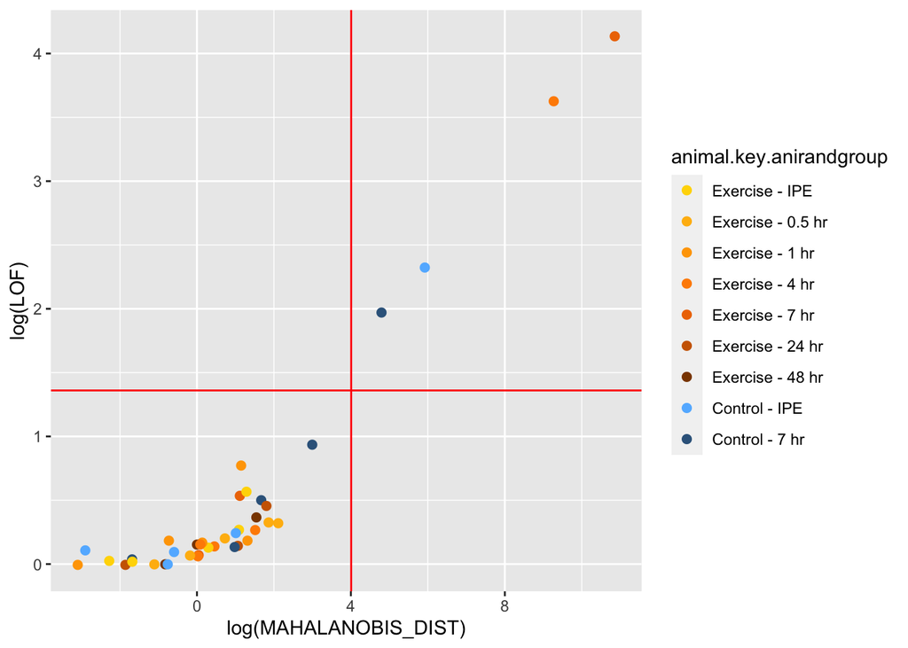

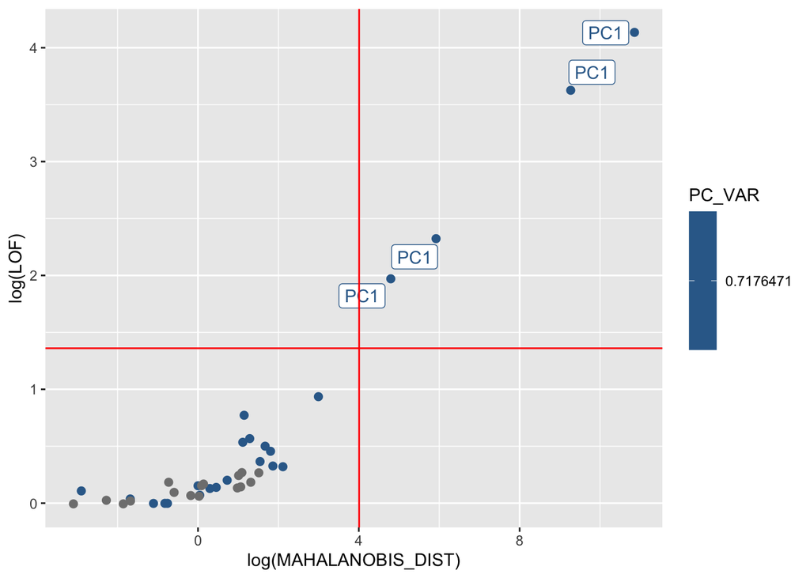

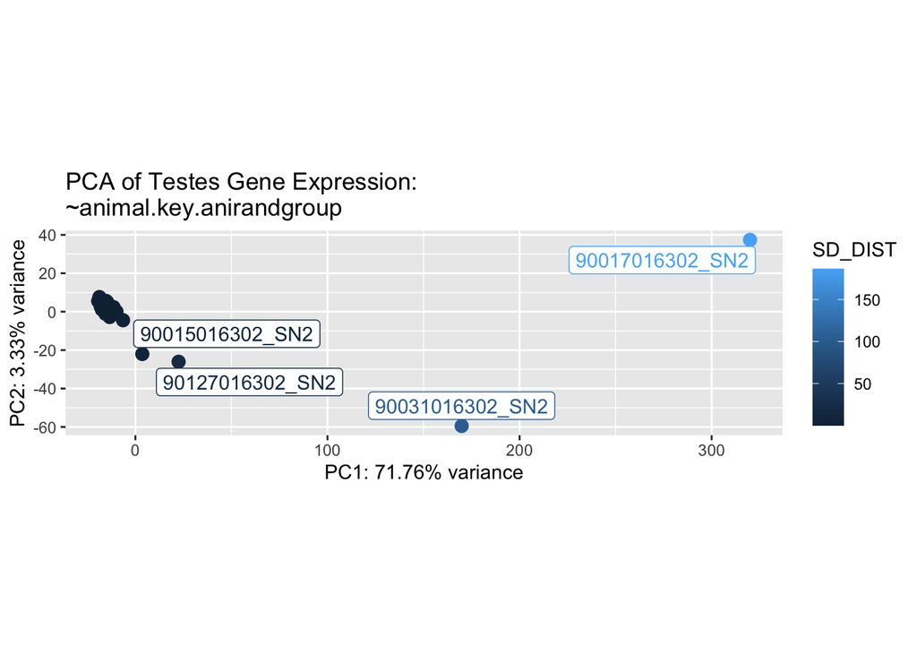

```r
################################################################################
################### Early Removal of Outliers ##################################
################################################################################

# A few Hippocampus samples demonstrate considerably low Lib_molarity that cannot be compensated for. These samples will be treated as outliers and removed.
if(TISSUE %in% c('Hippocampus','Testes')){
  if(TISSUE == 'Hippocampus'){
    pri_var <- 'Lib_molarity'
  }else if(TISSUE == 'Testes'){
    pri_var <- 'Lib_frag_size..bp.'
    #pri_var <- 'Lib_molarity..nM.'
  }
  pca <- prcomp(t(assay(rld)), scale. = F)
  percentVar <- pca$sdev^2/sum(pca$sdev^2)
  PC <- pca$x %>% as.data.frame()
  PC$sample_key <- row.names(pca$x)
  df_plot <- data.frame(PC = seq_along(pca$sdev^2/sum(pca$sdev^2)),
                        VAR = pca$sdev^2/sum(pca$sdev^2)) %>%
    mutate(ELBOW = ifelse(PC < elbow_finder(PC,VAR)[1], 'UPPER', 'FORE'))
  PC_meta <- t(pca$x) %>%
    as_tibble() %>%
    mutate(PC = seq_along(pca$sdev^2/sum(pca$sdev^2))) %>%
    mutate(VAR = pca$sdev^2/sum(pca$sdev^2)) %>%
    mutate(ELBOW = ifelse(PC < elbow_finder(PC,VAR)[1], 'UPPER', 'FORE')) %>%
    filter(ELBOW == 'UPPER') %>%
    mutate(PC = as.character(sprintf('PC%d',PC))) %>%
    filter(PC %in% c('PC1','PC2','PC3','PC4'))
  # Reset the pca object
  pca <- prcomp(t(assay(rld)), scale. = F,
                rank. = elbow_finder(df_plot$PC,df_plot$VAR)[1])

  # Collect Standard Deviations
  pca$sd <- apply(pca$x, 2, function(x) abs(x - median(x)) / mad(x))
  join_meta <- PC_meta[,c('PC','VAR')]
  names(join_meta) <- c('SD_DIST_PC','PC_VAR')
  PC <- PC %>%
    select(
      c(sprintf('PC%d',1:(elbow_finder(df_plot$PC,df_plot$VAR)[1])),'sample_key')) %>%
    mutate(sample_n = seq_along(PC1)) %>%
    mutate(SD_DIST = apply(pca$x, 2, function(x) abs(x - median(x)) / mad(x)) %>%
             apply(1, max)) %>%
    mutate(SD_DIST_PC = colnames(pca$sd)[apply(pca$sd,1,which.max)]) %>%
    mutate(TUKEY_OUTLIER = ifelse(SD_DIST > 6, 'Outlier', 'Normal')) %>%
    mutate(MAHALANOBIS_DIST = dist_ogk(pca$x)) %>%
    # Bonferroni correction
    mutate(MAHALANOBIS_FDR = pchisq(MAHALANOBIS_DIST, df = elbow_finder(df_plot$PC,df_plot$VAR)[1], lower.tail = FALSE)*length(MAHALANOBIS_DIST)) %>%
    mutate(MAHALANOBIS_OUTLIER = ifelse(MAHALANOBIS_FDR <= 0.05,
                                        'Outlier', 'Normal')) %>%
    mutate(LOF = LOF(pca$x, log = F)) %>%
    left_join(y = col_data, by = 'sample_key') %>%
    left_join(y = join_meta, by = 'SD_DIST_PC') %>%
    arrange(desc(SD_DIST))
  p <- PC %>%
    mutate(PC_LABEL = ifelse(log(LOF) > tukey_mc_up(log(PC$LOF)) |
                               log(MAHALANOBIS_DIST) > tukey_mc_up(log(PC$MAHALANOBIS_DIST)), SD_DIST_PC, '')) %>%
    ggplot(aes(x = log(MAHALANOBIS_DIST), y = log(LOF), color = animal.key.anirandgroup)) +
    geom_point(size = 2) +
    scale_color_manual(values=ec_colors) +
    geom_vline(xintercept = tukey_mc_up(log(PC$MAHALANOBIS_DIST)), color = 'red') +
    geom_hline(yintercept = tukey_mc_up(log(PC$LOF)),  color = 'red')
  plot(p)
  # Examine the variance from of the PC that is associated with the outlier
  p <- PC %>%
    mutate(PC_LABEL = ifelse(log(LOF) > tukey_mc_up(log(PC$LOF)) |
                               log(MAHALANOBIS_DIST) > tukey_mc_up(log(PC$MAHALANOBIS_DIST)), SD_DIST_PC, '')) %>%
    ggplot(aes(x = log(MAHALANOBIS_DIST), y = log(LOF), color = PC_VAR)) +
    geom_point(size = 2) +
    geom_label_repel(aes(label=PC_LABEL)) +
    #geom_label_repel(aes(label=sample_key)) +
    geom_vline(xintercept = tukey_mc_up(log(PC$MAHALANOBIS_DIST)), color = 'red') +
    geom_hline(yintercept = tukey_mc_up(log(PC$LOF)),  color = 'red')
  plot(p)
  p <- PC %>%
    mutate(OUTLIER = ifelse(log(LOF) > tukey_mc_up(log(PC$LOF)) |
                              log(MAHALANOBIS_DIST) > tukey_mc_up(log(PC$MAHALANOBIS_DIST)), sample_key, '')) %>%
    ggplot(aes(x = PC1, y = PC2, color = SD_DIST)) +
    geom_point(size = 3) +
    coord_equal() +
    geom_label_repel(aes(label=OUTLIER)) +
    xlab(paste0('PC1: ',round(percentVar[1]*100,2),'% variance')) +
    ylab(paste0('PC2: ',round(percentVar[2]*100,2),'% variance')) +
    ggtitle(paste0('PCA of ',TISSUE,' Gene Expression:\n',FINAL_FORMULA))
  plot(p)
  tod_cols <- col_data %>%
    filter(Tissue == TISSUE) %>%
    filter(sample_key %!in% OUTLIERS) %>%
    filter(!is.na(animal.registration.sex))
  rownames(tod_cols) <- tod_cols$sample_key
  nona_sams <- tod_cols %>%
  filter(!is.na(specimen.collection.t_death_hour)) %>%
  filter(!is.na(animal.registration.sex)) %>%
  select(sample_key) %>% unlist() %>% as.character()
  tod_counts <- count_data[,nona_sams]
  all(rownames(tod_cols) == colnames(tod_counts))
  design = ~ 1 # Primary variable needs to be last.
  title = paste0('Design: ',as.character(design))
  dds1 <- DESeqDataSetFromMatrix(countData = tod_counts,
                               colData = tod_cols,
                               design = design)
  zero_n <- dds1[(rowSums(counts(dds1))/ncol(dds1) < 1), ] %>%
  nrow() %>% as.character()
  reads_n <- 1
  keep <- rowSums(counts(dds1))/ncol(dds1) >= reads_n
  dds2 <- dds1[keep,]
  dds2
  dds <- dds2
  sort(colSums(assay(dds)))/1e6
  dds <- estimateSizeFactors(dds)
  summary(sizeFactors(dds))
  rld <- DESeq2::vst(dds, blind = FALSE)
  rs <- rowSums(counts(dds))
}
```

## Qualitative Assessment of Variance in Tissue

```r
# Qualitative Assessment of Variance in Tissue
################################################################################
#####     Qualitative Assessment of Variance in Tissue      ####################
################################################################################

# Examine the Annotations most strongly associated with PCs
################################################################################

# Find variables associated with PCs
pc_cor_df <- cor_PC_1_4(rld = rld, ntop = 20000, intgroups = names(tod_cols)) %>%
  filter(Adjusted_R_Sq > 0.2) %>%
  arrange(PC)
# Examine Variables of interest for Pcs 1 - 4
pc_cor_df %>%
  filter(PC %in% c(1:4))
```

```
## # A tibble: 2 x 3
##      PC Adjusted_R_Sq Condition
##   <int>         <dbl> <fct>
## 1     2         0.598 animal.registration.cagenumber
## 2     3         0.205 r_260_280
```

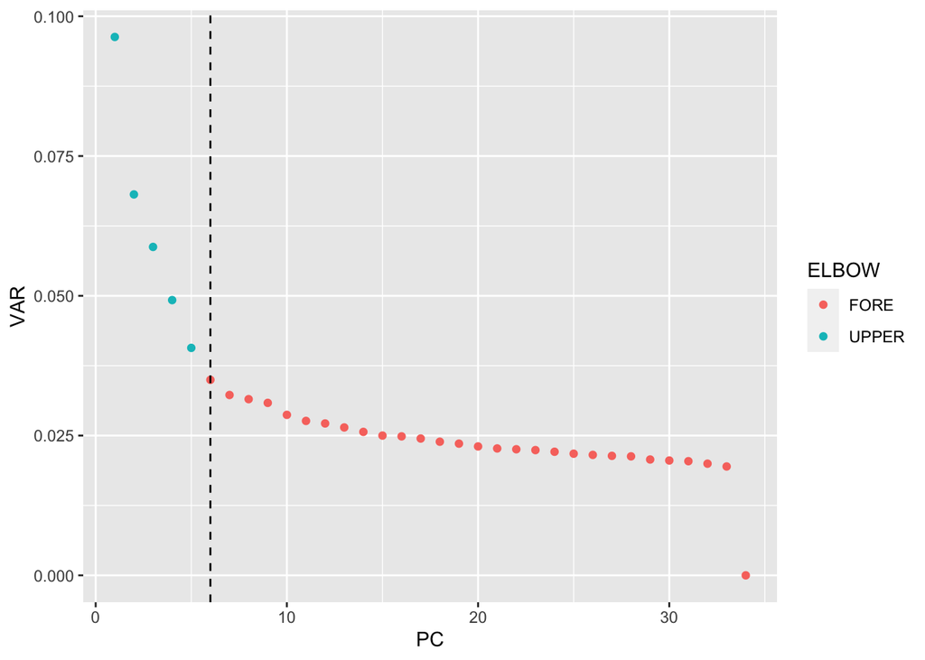

```r
# # Quick Test
# animal.key.batch %in% (pc_cor_df %>% filter(PC %in% c(1,2)) %>% select(Condition) %>% unlist() %>% as.character() %>% unique())

# Examine strength of PC
pca <- prcomp(t(assay(rld)), scale. = F)
df_plot <- data.frame(PC = seq_along(pca$sdev^2/sum(pca$sdev^2)),
                      VAR = pca$sdev^2/sum(pca$sdev^2)) %>%
  mutate(ELBOW = ifelse(PC < elbow_finder(PC,VAR)[1], 'UPPER', 'FORE'))
p <- df_plot %>%
  ggplot(aes(PC,VAR, color = ELBOW)) +
  geom_point() +
  geom_vline(xintercept = elbow_finder(df_plot$PC,df_plot$VAR)[1], linetype='dashed')
plot(p)
```

```r
# colData(rld) %>%
#   as.data.frame() %>% select(animal.key.anirandgroup,
#                         animal.registration.sex,
#                         animal_time_last_fed)

if(T){
# Visualize variables in PC's 1 - 2
voi12 <- pc_cor_df %>%
  filter(PC %in% c(1:2)) %>%
  select(Condition) %>% unlist() %>% as.character %>% unique()
# Plot the top variables associated with PCs 1 or 2
for( v in voi12){
  # Quick investigation of variables
  title_parts <- pc_cor_df %>%
    filter(Condition == v)
  title <- paste0(title_parts$Condition,'\nPC = ',
                  title_parts$PC,'; R2 = ',
                  round(title_parts$Adjusted_R_Sq,3))
  p <- DESeq2::plotPCA(rld, intgroup =v, ntop = 20000) +
    ggtitle(title) +
    coord_equal()
  plot(p)
}
}
```

[output not shown]

```r
if(T){
  # Visualize variables in PC's 3 - 4
  voi34 <- pc_cor_df %>%
    filter(PC %in% c(3:4)) %>%
    select(Condition) %>% unlist() %>% as.character %>% unique()

  # Prepare the data for PC3 and PC4 visualization
  pca <- prcomp(t(assay(rld)), scale. = F)
  df_plot <- pca$x %>% as.data.frame()
  df_plot$sample_key <- row.names(df_plot)
  df_plot <- df_plot %>%
    left_join(y = col_data, by = 'sample_key')
  percentVar <- pca$sdev^2/sum(pca$sdev^2)
  # Plot the top variables associated with PCs 1 or 2
  for( v in voi34){
    # Quick investigation of variables
    title_parts <- pc_cor_df %>%
      filter(Condition == v)
    title <- paste0(title_parts$Condition,'\nPC = ',
                    title_parts$PC,'; R2 = ',
                    round(title_parts$Adjusted_R_Sq,3))
    p <- df_plot %>%
      ggplot(aes(x = PC3, y = PC4, color = !!as.symbol(v))) +
      geom_point(size = 2) +
      coord_equal() +
      xlab(paste0('PC3: ',round(percentVar[3]*100,2),'% variance')) +
      ylab(paste0('PC4: ',round(percentVar[4]*100,2),'% variance')) +
      ggtitle(title)
    plot(p)
  }
}
```

[output not shown]

```r
################################################################################
###### Manual Annotation Opportunity: Fill in MIS_ID_VAR variable ##############
################################################################################

# Examine a labled PCA Plot
################################################################################
if(TISSUE %!in% c('Ovaries','Testes')){
  for(mis_id_var in MIS_ID_VAR){
    if(MIS_ID_VAR == 'None'){
      mis_id_var <- 'animal.registration.sex'
      }
  #mis_id_var <- MIS_ID_VAR[1]
  print(mis_id_var)
# Examine metadata varibales most correlated with suspected misidentified samples to determine if there is an effect are genuine
cor_out_df <- cor_outlier2(rld = rld, ntop = 20000, intgroups = names(colData(rld)))
cor_out_df <- cor_out_df %>%
  filter(Condition != 'outlier')
cor_out_df

# Show a PCA plot labeled with suspected misidentified samples
mypar()
pcaData <- DESeq2::plotPCA(rld,
                           intgroup=c(mis_id_var, 'sample_key','animal.key.anirandgroup',
                                      'animal.registration.sex','animal.registration.cagenumber'),
                           returnData=TRUE, ntop = 20000)
percentVar <- round(100 * attr(pcaData, 'percentVar'))
#pdf(paste0(WD,'/plots/20200505_rnaseq-',TIS,'-PCA-naive-modeling_steep.pdf'),
#    width = 6, height = 4)
p <- pcaData %>%
  mutate(sample_key = as.character(sample_key)) %>%
  mutate(sample_misid_suspect = ifelse(sample_key %in% MIS_SUS, sample_key, '')) %>%
  ggplot(aes_string('PC1', 'PC2', color=mis_id_var)) +
  geom_point(size=3) +
  #geom_label_repel(aes(label=sample_key),hjust=0, vjust=0) +
  geom_label_repel(aes(label=sample_misid_suspect),hjust=0, vjust=0) +
  xlab(paste0('PC1: ',percentVar[1],'% variance')) +
  ylab(paste0('PC2: ',percentVar[2],'% variance')) +
  #coord_fixed() +
  ggtitle(paste0('PCA of ',TISSUE,' Gene Expression:\nNaive Model (~ 1)')) +
  guides(color=guide_legend(title=mis_id_var)) +
  theme(legend.title=element_blank())
plot(p)
#dev.off()
# Examine the PCA annotated with variables of interest
p <- pcaData %>%
  mutate(sample_key = as.character(sample_key)) %>%
  mutate(sample_misid_suspect = ifelse(sample_key %in% MIS_SUS, sample_key, '')) %>%
  ggplot(aes(PC1, PC2, color=animal.key.anirandgroup)) +
  geom_point(size=3) +
  #geom_label_repel(aes(label=!!as.symbol(mis_id_var)),hjust=0, vjust=0) +
  xlab(paste0('PC1: ',percentVar[1],'% variance')) +
  ylab(paste0('PC2: ',percentVar[2],'% variance')) +
  #coord_fixed() +
  ggtitle(paste0('PCA of ',TISSUE,' Gene Expression')) +
  guides(color=guide_legend(title='animal.key.anirandgroup')) +
  scale_color_manual(values=ec_colors) +
  theme(legend.title=element_blank())
plot(p)

# Plot Sex-Specific Plots
################################################################################
# Variables of interest
male_tis <- (tod_cols %>%
                     filter(animal.registration.sex == 'Male'))$sample_key %>%
        as.character()
female_tis <- (tod_cols %>%
                       filter(animal.registration.sex == 'Female'))$sample_key %>%
        as.character()
Y_genes <- Y_ens_id[Y_ens_id %in% row.names(assay(rld))]
X_genes <- X_ens_id[X_ens_id %in% row.names(assay(rld))]
sex <- tod_cols$animal.registration.sex
group <- tod_cols$animal.registration.sex

#### Predict the sex of reference samples (all samples for that matter) by calculating the median expression of genes on the Y chromosome. We should expect a bimodal distribution with males demonstrating significantly higher median expression.
chryexp <- colMeans(assay(rld)[Y_genes,])
chryexp_df <- data.frame('counts' = chryexp)
chryexp_df$sample <- row.names(chryexp_df) %>% as.factor()
chryexp_df <- chryexp_df %>%
        mutate(sex = ifelse(sample %in% male_tis, 'Male', 'Female'))

# Visualize genes on the Y Chromosome
##############################################
##### If we create a histogram of the median gene expression values on chromosome Y, we should expect to see a bimodal distribution.
mypar()
p <- chryexp_df %>%
  mutate(plot_labs = ifelse(sample %in% MIS_ID, as.character(sample), '')) %>%
  ggplot(aes(counts, colour = sex)) +
  geom_freqpoly(alpha = 0.6) +
  xlab('Median counts on Y genes (normalized)') +
  ylab('Frequency') +
  ggtitle('Frequency Polyplot & Sample Dotplot: \nSamples plotted by Y gene coverage (median)') +
  geom_dotplot(aes(fill = sex), alpha = 0.5) +
  #geom_text_repel(aes(label = sample), y = 2)
  geom_text_repel(aes(label = plot_labs), box.padding = unit(2, 'lines'), y = 0)
plot(p)

################################################################################
###### Manual Annotation Opportunity: Fill in MIS_SUS variable #################
################################################################################

# ## Sample Classification: High Dimension (Gene) Outlier Prediction + Supervised

# Sample Classification: High Dimension Outlier Prediction + Supervised
################################################################################
##     Sample Classification: High Dimension Outlier Prediction + Supervised #
################################################################################

# (iii) standardization of the data so that the expression measures for each array have mean 0 and variance 1 across genes.
edata <- scale(assay(rld))

# check that we get mean of 0 and sd of 1
apply(edata , 2, mean)
apply(edata , 2, sd)

 ## Reassign Annotation Groups to MisIdentified Samples: Outlier Detection (Per Gene)

# Reassign Annotation Groups to MisIdentified Samples
################################################################################
#####     Reassign Annotation Groups to MisIdentified Samples      #############
################################################################################
# TODO: Add a conditional statement if samples were misidentieid or not

# identify multivariate outliers
x.out <- pcout(edata, makeplot = T)

# Create a dataframe with 3 columns: gene, weight_combined, gene_index
df_out <- data.frame(names(x.out$wfinal), x.out$wfinal) %>% as_tibble()
names(df_out) <- c('gene', 'weight_combined')
df_out$index <- row.names(df_out)
```

```r
# Arrange the dataframe by weight
df_out <- df_out %>%
  arrange(weight_combined)

# Plot the Outliers by combined weight
p <- df_out %>%
  sample_n(500) %>%
  ggplot(aes(index, weight_combined)) +
  geom_point(alpha = 0.3) +
  geom_hline(yintercept = 0.1) +
  ggtitle('Weights of 500 randomly selected genes')
plot(p)

# Number of strong outlier genes
genes_out <- df_out %>%
  filter(weight_combined < 0.10) %>%
  select(gene) %>% unlist() %>% as.character()

# Unsupervised Model
################################################################################
set.seed(100)
rld_out <- rld[names(rld) %in% genes_out,]
df <- t(assay(rld_out)) %>% as.data.frame()
df$sample_key <- row.names(df)
join_df <- col_data %>%
  dplyr::select(animal.registration.sex, sample_key, animal.key.anirandgroup)
df <- left_join(df,join_df, by = 'sample_key')
row.names(df) <- make.names(df$animal.registration.sex, unique = TRUE)
#df <- df %>%
#  filter(animal.key.anirandgroup %!in% c('Control - IPE', 'Control - 7 #hr',
#                                         'Exercise - 24 hr', 'Exercise #- 48 hr',
#                                         'Exercise - 7 hr'))
d <- dist( df )
hc <- hclust(d)
sex <- as.character(df$animal.registration.sex)
sample <- as.character(df$sample_key)
ex_grp <- as.character(df$animal.key.anirandgroup)
myplclust(hc, labels=sex, lab.col=as.fumeric(sex), cex=1)
myplclust(hc, labels=sample, lab.col=as.fumeric(sex), cex=1)

# Supervised Model
################################################################################
# Classification Model, Predict Class with outlier gene set
set.seed(100)
rld_out <- rld[names(rld) %in% genes_out,]
# Remove the Sample in question
rld_mis <- rld_out[,rld_out$sample_key %in% MIS_SUS]
rld_out <- rld_out[,rld_out$sample_key %!in% MIS_SUS]

# Create a train and test set
rld_out[[mis_id_var]] <- as.character(rld_out[[mis_id_var]])
rld_out[[mis_id_var]] <- as.factor(rld_out[[mis_id_var]])
index = createDataPartition(y=rld_out[[mis_id_var]], p=0.7, list=FALSE)
sample_train <- as.character(rld_out$sample_key[index])
sample_test <- as.character(rld_out$sample_key[-index])
rld_train = rld_out[,rld_out$sample_key %in% sample_train]
rld_test = rld_out[,rld_out$sample_key %in% sample_test]
# Reorganize the train and test DFs
join_df <- tod_cols %>%
  select('sample_key', all_of(mis_id_var))
# Train
train_df <- data.frame(t(assay(rld_train)))
train_df$sample_key <- row.names(train_df)
train_df <- train_df %>%
  left_join(join_df, by = c('sample_key')) %>%
  as_tibble() %>%
  select(-sample_key)
# Test
test_df <- data.frame(t(assay(rld_test)))
test_df$sample_key <- row.names(test_df)
test_df <- test_df %>%
  left_join(join_df, by = c('sample_key')) %>%
  as_tibble() %>%
  select(-sample_key)
# Misidentified
mis_df <- data.frame(t(assay(rld_mis)))
mis_df$sample_key <- row.names(mis_df)
mis_df <- mis_df %>%
  left_join(join_df, by = c('sample_key')) %>%
  as_tibble() %>%
  select(-sample_key)
# Double check (must be true)
nrow(colData(rld)) == nrow(train_df) + nrow(test_df) + nrow(mis_df)

# genes to remove from model
x = nearZeroVar(train_df, saveMetrics = TRUE)
str(x, vec.len=2)
# The Zero variance predictors
x[x[,'zeroVar'] > 0, ]
# The near Zero variance predictors
x[x[,'zeroVar'] + x[,'nzv'] > 0, ]

# prepare training scheme
control <- trainControl(method='repeatedcv', number = 10, repeats = 10)
control <- trainControl(method='cv')
#control <- trainControl(method='LOOCV')
design <- formula(paste0(mis_id_var,' ~ .'))

# Random Forest
######################
# Set up the random forest tuning grid
# TODO: Automate mtry selection
grid_rf <- expand.grid(mtry = c(50,100,250,500,750,1000))
set.seed(100)
design <- formula(paste0(mis_id_var,' ~ .'))
rf.fit <- train(design, data=train_df,
                method = 'rf',
                ntree = 1000,
                trControl = control,
                tuneGrid = grid_rf)

# Examine model
rf.fit

# Visualize feature importance
rfImp <- varImp(rf.fit, scale = FALSE)
plot(rfImp, top = 25, scales = list(y = list(cex = .95)))
# Annotate gene ids with symbols
row.names(rfImp$importance) <- mapIds(org.Rn.eg.db, row.names(rfImp$importance),
                                      'SYMBOL', 'ENSEMBL') %>%
  make.names(unique=TRUE)
plot(rfImp, top = 25, scales = list(y = list(cex = .95)))

pred_sex = predict(rf.fit, test_df)
table(pred_sex, test_df[[mis_id_var]])
pred.accuracy = round(mean(pred_sex == test_df[[mis_id_var]])*100,2)
pred.accuracy

# For sake of conditions below
correct_df <- mis_df
if(nrow(mis_df) >= 1){
  true_var = predict(rf.fit, mis_df)
  true_df <- col_data %>%
    filter(sample_key %in% MIS_SUS) %>%
    select('sample_key', all_of(mis_id_var))
  names(true_df) <- c('Recorded_sample_key', 'Recorded_Var')
  true_df$Corrected_Var <- true_var
  if(TISSUE %in% c('Hypothalamus')){
    true_df$Corrected_sample_key <- c(as.character(true_df$Recorded_sample_key[2]),
                                      as.character(true_df$Recorded_sample_key[1]))
  }
  # Remove samples that were correctly identified
  if(nrow(true_df %>%
          filter(Recorded_Var != Corrected_Var)) >= 1){
    correct_df <- true_df %>%
      filter(Recorded_Var != Corrected_Var) %>%
      mutate(Corrected_sample_key = as.character(Corrected_sample_key))
  }
}

################################################################################
###### Manual Annotation Opportunity: Fill in MIS_ID variable ##################
################################################################################

# TODO: Improve this adjustment of metadata to be independent of mis_id_var class
# TODO: Adjust the vial label
if(TISSUE %in% c('Hypothalamus')){
    for(i in 1:nrow(correct_df)){
      col_data <- col_data %>%
        mutate(sample_key =
                 ifelse(
                   vial_label == (correct_df[i,]$Recorded_sample_key %>%
                                    as.character() %>%
                                    strsplit(split = '_') %>%
                                    unlist())[1],
                   as.character(correct_df[i,]$Corrected_sample_key),
                   as.character(sample_key)
                 ))
  }
}
```

```r
# Save the updated metadata
################################################################################
if(nrow(true_df %>%
        filter(Recorded_Var != Corrected_Var)) >= 1){
  # # Meta Data
  meta_file <- paste0(WD,'/data/20200603_rnaseq-meta-pass1a-stanford-sinai-proc_steep.rds')
  saveRDS(col_data, file = meta_file)

  # Update the rld object
  ################################################################################
  tod_cols <- col_data %>%
    filter(Tissue == TISSUE) %>%
    filter(!is.na(animal.registration.sex))
  rownames(tod_cols) <- tod_cols$sample_key
  nona_sams <- tod_cols %>%
    filter(!is.na(specimen.collection.t_death_hour)) %>%
    filter(!is.na(animal.registration.sex)) %>%
    select(sample_key) %>% unlist() %>% as.character()
  tod_counts <- count_data[,nona_sams]
  all(rownames(tod_cols) == colnames(tod_counts))
  dds <- DESeqDataSetFromMatrix(countData = tod_counts,
                                      colData = tod_cols,
                                      design = formula('~ 1'))
  dds <- dds[rowSums(counts(dds))/ncol(dds) >= 1,]
  dds <- estimateSizeFactors(dds)
  rld <- DESeq2::vst(dds, blind = F)
}
}
}

################################################################################
#########     Manual Annotation Opportunity: Assign PRI_VAR      ###############
################################################################################
```

## Correct for Variance: Examine Genes Driving Primary Variance of Interest

```r
################################################################################
#########     Examine Genes Driving Primary Variance of Interest      ##########
################################################################################

for(pri_var in PRI_VAR){
  if(PRI_VAR == 'None'){
    pri_var <- 'animal.registration.sex'
  }
  #pri_var <- PRI_VAR[1]
  print(pri_var)
  # Find variables associated with PCs
  pc_cor_df <- cor_PC_1_4(rld = rld, ntop = 20000, intgroups = names(colData(rld))) %>%
    filter(Adjusted_R_Sq > 0.2) %>%
    arrange(PC)
  # Examine Variables of interest for Pcs 1 and 2
  p <- pc_cor_df %>%
    filter(PC %in% c(1:4))
  print(p)

  if(T){
  # Visualize variables in PC's 1 and 2
  voi <- pc_cor_df %>%
    filter(PC %in% c(1,2)) %>%
    select(Condition) %>% unlist() %>% as.character %>% unique()
  # Plot the top variables associated with PCs 1 or 2
  for( v in voi){
    #v <- 'RNA_extr_conc'
    # Quick investigation of variables
    title_parts <- pc_cor_df %>%
      filter(Condition == v)
    title <- paste0(title_parts$Condition,'\nPC = ',
                    title_parts$PC,'; R2 = ',
                    round(title_parts$Adjusted_R_Sq,3))
    p <- DESeq2::plotPCA(rld, intgroup =v, ntop = 20000) +
      ggtitle(title)
    plot(p)
  }
  }
  if(T){
  # Visualize variables in PC's 3 - 4
  voi34 <- pc_cor_df %>%
    filter(PC %in% c(3:4)) %>%
    select(Condition) %>% unlist() %>% as.character %>% unique()

  # Prepare the data for PC3 and PC4 visualization
  pca <- prcomp(t(assay(rld)), scale. = F)
  df_plot <- pca$x %>% as.data.frame()
  df_plot$sample_key <- row.names(df_plot)
  df_plot <- df_plot %>%
    left_join(y = col_data, by = 'sample_key')
  percentVar <- pca$sdev^2/sum(pca$sdev^2)
  # Plot the top variables associated with PCs 1 or 2
  for( v in voi34){
    # Quick investigation of variables
    title_parts <- pc_cor_df %>%
      filter(Condition == v)
    title <- paste0(title_parts$Condition,'\nPC = ',
                    title_parts$PC,'; R2 = ',
                    round(title_parts$Adjusted_R_Sq,3))
    p <- df_plot %>%
      ggplot(aes(x = PC3, y = PC4, color = !!as.symbol(v))) +
      geom_point(size = 2) +
      coord_equal() +
      xlab(paste0('PC3: ',round(percentVar[3]*100,2),'% variance')) +
      ylab(paste0('PC4: ',round(percentVar[4]*100,2),'% variance')) +
      ggtitle(title)
    plot(p)
  }
  }

  # If PC1 Unknown, then create a pho PC1 variable (binary), perform DE + Pathway analysis to investigate
  ######################################
  # Make this if statement true if you'd like to examine a PC of interest that is not obviously correlated with a meta data variable of interest
  if(TISSUE %in% c('Aorta','Ovaries','Testes')){
    # Fill in manually
    PC_THRESH <- 0
    pc_int <- 'PC1'
    #all(tod_cols$sample_key == row.names((prcomp(t(assay(rld)), scale. = F))$x))
    tod_cols$PC_INT <- (prcomp(t(assay(rld)), scale. = F))$x %>%
      as.data.frame() %>% select(all_of(pc_int)) %>% unlist() %>% as.numeric()
    tod_cols <- tod_cols %>%
      mutate(PC_UNKN = factor(ifelse(PC_INT < PC_THRESH, '0', '1'), levels = c('0','1')))
    pri_var <- 'PC_UNKN'
    # Examine PCA
    df_plot <- (prcomp(t(assay(rld)), scale. = F))$x %>%
      as.data.frame()
    df_plot$sample_key <- row.names(df_plot)
    df_plot <- df_plot %>%
      left_join(y = col_data, by = 'sample_key')
    percentVar <- pca$sdev^2/sum(pca$sdev^2)
    p <- df_plot %>%
      ggplot(aes_string(x = pc_int, y = 'PC2', color = 'animal.registration.sex')) +
      geom_point(size = 2) +
      coord_equal() +
      xlab(paste0('PC1: ',round(percentVar[1]*100,2),'% variance')) +
      ylab(paste0('PC2: ',round(percentVar[2]*100,2),'% variance'))
    plot(p)
    pri_var <- PRI_VAR[1]
    if(pri_var == 'None'){pri_var <- 'animal.registration.sex'}
  }

  # DE Test for Variable (Ensure factors are properly ordered)
  ( design = formula(paste0('~ 1')) ) # Primary variable needs to be last.
  dds_vp <- DESeqDataSetFromMatrix(countData = tod_counts,
                                   colData = tod_cols,
                                   design = design)
  dds_vp <- dds_vp[rowSums(counts(dds_vp))/ncol(dds_vp) >= 1,]
  dds_vp <- estimateSizeFactors(dds_vp)
  res_vp <- DESeq(dds_vp) %>%
    results(alpha = 0.05,lfcThreshold=0.5)

  if(pri_var == 'animal.registration.sex') {
    # Adjust the result dataframe
    res_vp <- res_vp %>%
      as.data.frame() %>%
      mutate(ENSEMBL_RAT = row.names(res_vp)) %>%
      mutate(SIG = ifelse((abs(log2FoldChange) >= 0.5 & padj <= 0.05), 'SIG','NS')) %>%
      mutate(CHROM = factor(case_when(ENSEMBL_RAT %in% Y_ens_id ~ 'Y',
                                      ENSEMBL_RAT %in% X_ens_id ~ 'X',
                                      ENSEMBL_RAT %!in% c(X_ens_id,Y_ens_id) ~ 'AUTO'),
                            levels = c('X', 'Y', 'AUTO'))) %>%
      arrange(padj) %>%
      as_tibble()
    res_vp
    top20 <- res_vp %>%
      head(n = 20) %>%
      select(ENSEMBL_RAT) %>% unlist() %>% as.character()
    n_sig <- res_vp %>% filter(SIG == 'SIG') %>% nrow()
    # Generate a volcano plot
    p <- res_vp %>%
      ggplot(aes(log2FoldChange, -log10(padj), color = CHROM, size = CHROM)) +
      geom_point(alpha = 0.5) +
      geom_hline(yintercept = -log10(0.05), linetype='dashed') +
      geom_vline(xintercept = 0.5, linetype='dashed') +
      geom_vline(xintercept = -0.5, linetype='dashed') +
      ggtitle('DE Genes from Females to Males:
Adjusted p-value <= 0.05; |Log2FC| >= 0.5') +
      ylab(bquote('-'~Log[10]~ 'Adjusted p-value (Bonferroni)')) +
      scale_color_manual(values=c('blue', 'red', 'grey')) +
      scale_size_manual(values=c(3, 3, 2)) +
      theme_bw()
    plot(p)
    # Generate an accompanying pvalue histogram
    p <- res_vp %>%
      ggplot(aes(x = padj, fill = CHROM)) +
      #geom_freqpoly() +
      ggtitle('DE Genes Females to Males (adjusted p-value <= 0.05)') +
      geom_dotplot(aes(x = padj), dotsize = 0.5, alpha = 0.5) +
      geom_vline(xintercept = 0.05, linetype='dashed') +
      xlab('Adjusted p-value (Bonferroni)') +
      ylab('Density') +
      scale_fill_manual(values=c('blue', 'red', 'grey')) +
      theme_bw()
    plot(p)
  } else {
    res_vp <- res_vp %>%
      as.data.frame() %>%
      mutate(ENSEMBL_RAT = row.names(res_vp)) %>%
      mutate(SIG = ifelse((abs(log2FoldChange) >= 0.5 & padj <= 0.05), 'SIG','NS')) %>%
      arrange(padj) %>%
      as_tibble()
    res_vp
    top20 <- res_vp %>%
      head(n = 20) %>%
      select(ENSEMBL_RAT) %>% unlist() %>% as.character()
    n_sig <- res_vp %>% filter(SIG == 'SIG') %>% nrow()
    # Generate a volcano plot
    p <- res_vp %>%
      mutate(SYMBOL_RAT = mapIds(org.Rn.eg.db, ENSEMBL_RAT, 'SYMBOL', 'ENSEMBL')) %>%
      #mutate(plot_label = ifelse(ENSEMBL_RAT %in% top20, SYMBOL_RAT, '')) %>%
      mutate(plot_label = ifelse(ENSEMBL_RAT %in% top20, ENSEMBL_RAT, '')) %>%
      ggplot(aes(log2FoldChange, -log10(padj), color = SIG)) +
      geom_point(alpha = 1) +
      #geom_label_repel(aes(label=plot_label),hjust=0, vjust=0) +
      #geom_text_repel(aes(label = plot_label), box.padding = unit(2, 'lines')) +
      geom_hline(yintercept = -log10(0.05), linetype='dashed') +
      geom_vline(xintercept = 0.5, linetype='dashed') +
      geom_vline(xintercept = -0.5, linetype='dashed') +
      ggtitle(paste0(pri_var,' DE Genes (n=',n_sig,'; dir:',levels(col_data[[pri_var]])[1],' to ',levels(col_data[[pri_var]])[2],')
Adjusted p-value <= 0.05; |Log2FC| >= 0.5')) +
      ylab(bquote('-'~Log[10]~ 'Adjusted p-value (Bonferroni)')) +
      scale_color_manual(values=c('grey','black')) +
      theme_bw()
    plot(p)
    # Generate an accompanying pvalue histogram
    p <- res_vp %>%
      ggplot(aes(x = padj, fill = SIG)) +
      #geom_freqpoly() +
      ggtitle(paste0(pri_var,' DE Genes (n=',n_sig,'; dir:',levels(col_data[[pri_var]])[1],' to ',levels(col_data[[pri_var]])[2],')
Adjusted p-value <= 0.05; |Log2FC| >= 0.5')) +
      geom_dotplot(aes(x = padj), dotsize = 0.5, alpha = 0.5) +
      geom_vline(xintercept = 0.05, linetype='dashed') +
      xlab('Adjusted p-value (Bonferroni)') +
      ylab('Density') +
      scale_fill_manual(values=c('grey','black')) +
      theme_bw()
    plot(p)
  }
```

```r
    # Pathway Analysis on DE genes
    ################################################################################
    de_df <- res_vp %>% filter(SIG == 'SIG')
    # Convert gene symbols to mouse orthologs
    de_df <- rat_mouse_ortho(as.data.frame(de_df), column = 'ENSEMBL_RAT', direction = 'rat2mouse')

    # COllect the gene symbols
    de_df$SYMBOL_MOUSE <- mapIds(org.Mm.eg.db, de_df$ENSEMBL_MOUSE, 'SYMBOL', 'ENSEMBL')
    de_df$SYMBOL_MOUSE <- as.character(de_df$SYMBOL_MOUSE)

    # Collect gene symbols
    symbol_up <- de_df %>%
      filter(!is.na(SYMBOL_MOUSE)) %>%
      filter(log2FoldChange > 0) %>%
      select(SYMBOL_MOUSE) %>% unlist() %>% unique() %>% as.character()
    symbol_down <- de_df %>%
      filter(!is.na(SYMBOL_MOUSE)) %>%
      filter(log2FoldChange < 0) %>%
      select(SYMBOL_MOUSE) %>% unlist() %>% unique() %>% as.character()

    # Collect the desired pathways to query for enrichment
    desired <- c('KEGG_2019_Mouse')
    # db <- c('KEGG_2019_Mouse')
    enriched_up <- enrichr(symbol_up, desired)
    enriched_down <- enrichr(symbol_down, desired)
    n<-1
    enrichr_df <- data.frame()
    for(db in desired){
      # Collapse the data into flat format
      if(nrow(enriched_up[[desired]]) > 0){
        enriched_up[[n]]$Data.Base <- db
        enriched_up[[n]]$UPDOWN <- 'Up'
      }
      if(nrow(enriched_down[[desired]]) > 0){
        enriched_down[[n]]$Data.Base <- db
        enriched_down[[n]]$UPDOWN <- 'Down'
      }
      if(nrow(enriched_down[[desired]]) > 0){
        enrichr_df <- rbind(enrichr_df,enriched_up[[n]])
      }else if(nrow(enriched_up[[desired]]) > 0){
        enrichr_df <- rbind(enrichr_df,enriched_down[[n]])
      }else{
        enrichr_df <- rbind(enrichr_df,enriched_up[[n]],enriched_down[[n]])
      }
      n <- n + 1
    }
    # Generate a new column for the number of genes per enriched term
    if(nrow(enrichr_df) > 0){
    enrichr_df  <- enrichr_df %>% separate(Overlap, sep = '/', into = c('Overlap.N','Total.N'))
    enrichr_df$FDR_nlog <- -log(enrichr_df$Adjusted.P.value)
    # Filter the results
    enrichr_plot <- enrichr_df %>%
      filter(Total.N <= 500) %>%
      filter(Total.N >= 10) %>%
      filter(Adjusted.P.value <= 0.1) %>%
      arrange(desc(FDR_nlog)) %>%
      dplyr::slice(1:40) %>%
      group_by(Term, UPDOWN) %>%
      arrange(FDR_nlog) %>%
      ungroup()
    # Adjust levels
    enrichr_plot$UPDOWN <- factor(enrichr_plot$UPDOWN, levels = c('Up','Down'))
    # Create a special column that will allow for proper ordering of Pathways in Plot:
    # Ordering will have 2 priorities in this order: Up/Down regulation & -Log(FDR)
    enrichr_plot <- enrichr_plot %>%
      mutate(FDR_ord = ifelse(UPDOWN == 'Down', -FDR_nlog, FDR_nlog))
    # Visualize results with barplot
    #pdf(paste0(WD,'/plots/20200426_rnaseq-',TIS,'-pathways-sexmod-C0vsC7_steep.pdf'),
    #    width = 12, height = 6)
    p <- ggplot(enrichr_plot,
                aes(x=reorder(Term, FDR_ord), y=FDR_nlog, fill = UPDOWN)) +
      geom_bar(stat='identity') +
      coord_flip() +
      ylab('-Log(FDR)') +
      xlab('') +
      theme_linedraw() +
      guides(fill=guide_legend(title='Gene Expression')) +
      scale_fill_manual(values = c('Down' = '#00BFC4','Up' = '#F8766D')) +
      theme(panel.background = element_blank(),
            plot.background = element_blank(),
            strip.background = element_blank(),
            axis.text = element_text(size=12, colour = 'black'),
            axis.ticks = element_line(colour = 'black'),
            axis.title=element_text(size=12,face='bold'),
            strip.text = element_blank()) +
      theme(panel.grid.major = element_blank()) +
      ggtitle(paste0('Pathway Enrichment (',desired,')
',pri_var,' DE Genes (n=',n_sig,'; dir:',levels(col_data[[pri_var]])[1],' to ',levels(col_data[[pri_var]])[2],')
Adjusted p-value <= 0.05; |Log2FC| >= 0.5'))
    plot(p)
    #dev.off()
    print('No DE Genes')
    }

  #' ### Adjust Variance

  #+ Adjust Variance
  ################################################################################
  ########### Adjust Variance  #######################################
  ################################################################################
  if(PRI_VAR != 'None'){
    #pri_var <- 'animal.registration.sex'
    #pri_var <- 'calculated.variables.deathtime_after_fed'
    #pri_var <- 'animal_time_last_fed'
    # Set primary variable of interest
    if(TISSUE == c('Gastrocnemius_MSSM_1')){
      tod_cols <- col_data %>%
        filter(Tissue == 'Gastrocnemius') %>%
        filter(Seq_batch == 'MSSM_1') %>%
        filter(!is.na(animal.registration.sex))
    }else if(TISSUE == c('Gastrocnemius_Stanford_1')){
      tod_cols <- col_data %>%
        filter(Tissue == 'Gastrocnemius') %>%
        filter(Seq_batch == 'Stanford_1') %>%
        filter(!is.na(animal.registration.sex))
    }else if(TISSUE == c('Hippocampus')){
      tod_cols <- col_data %>%
        filter(Tissue == 'Hippocampus') %>%
        filter(sample_key %!in% OUTLIERS) %>%
        filter(!is.na(animal.registration.sex))
      }else{
      # Filter Samples (meta)
      tod_cols <- col_data %>%
        filter(Tissue == TISSUE) %>%
        filter(!is.na(animal.registration.sex))
    }
    rownames(tod_cols) <- tod_cols$sample_key

    # Collect samples without NA values in TOD
    nona_sams <- tod_cols %>%
      filter(!is.na(specimen.collection.t_death_hour)) %>%
      filter(!is.na(animal.registration.sex)) %>%
      select(sample_key) %>% unlist() %>% as.character()
    # Collect tissue specific counts
    tod_counts <- count_data[,nona_sams]
    #### Sanity Check: Ensure that the metadata rownames are identical to count matrix column names
    all(rownames(tod_cols) == colnames(tod_counts))

    # Create a design formula and load counts and supporting annotation into an S4 object (DESeq infrastructure)
    design = formula(paste0('~ ',pri_var)) # Primary variable needs to be last.
    dds_final <- DESeqDataSetFromMatrix(countData = tod_counts,
                                        colData = tod_cols,
                                        design = design)
    dds_final <- dds_final[rowSums(counts(dds_final))/ncol(dds_final) >= 1,]
    dds_final <- estimateSizeFactors(dds_final)
    rld_final <- DESeq2::vst(dds_final, blind = F)
    # The batch effect can only be removed with limma
    # https://support.bioconductor.org/p/76099/ (See Michael Love's Comment)
    assay(rld_final) <- limma::removeBatchEffect(assay(rld), rld[[pri_var]])
```

```
## [1] "animal.registration.sex"
## # A tibble: 2 x 3
##      PC Adjusted_R_Sq Condition
##   <int>         <dbl> <fct>
## 1     2         0.598 animal.registration.cagenumber
## 2     3         0.205 r_260_280
```

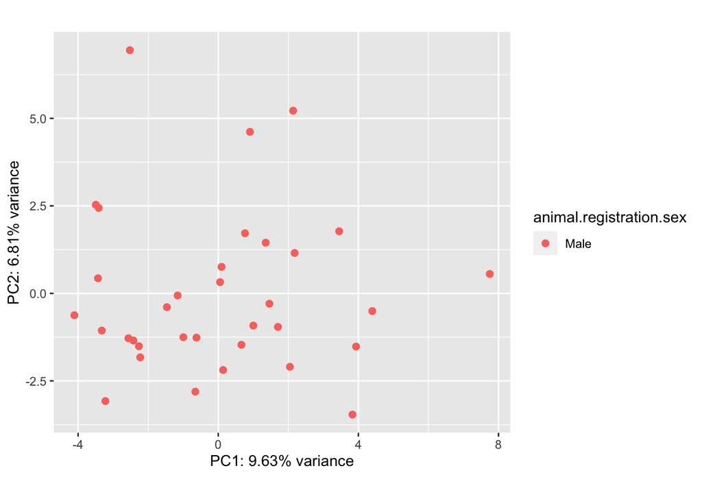

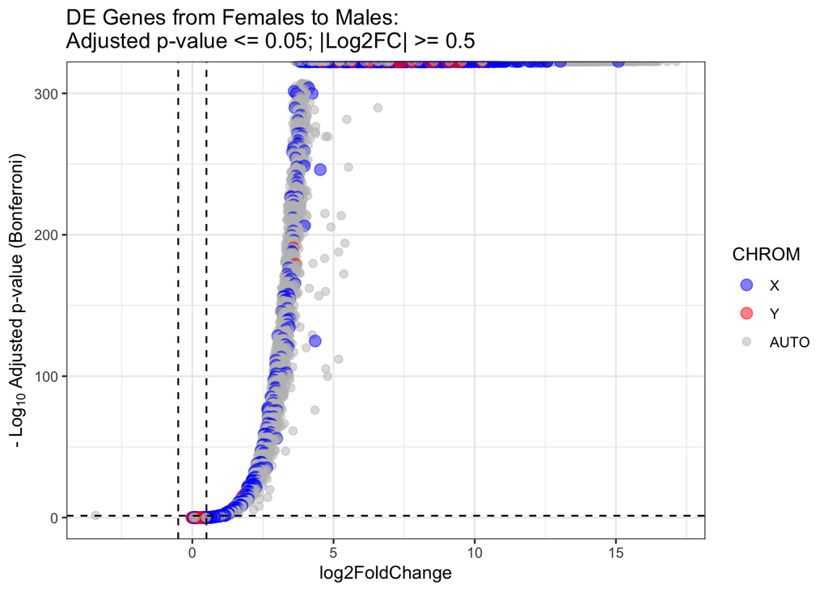

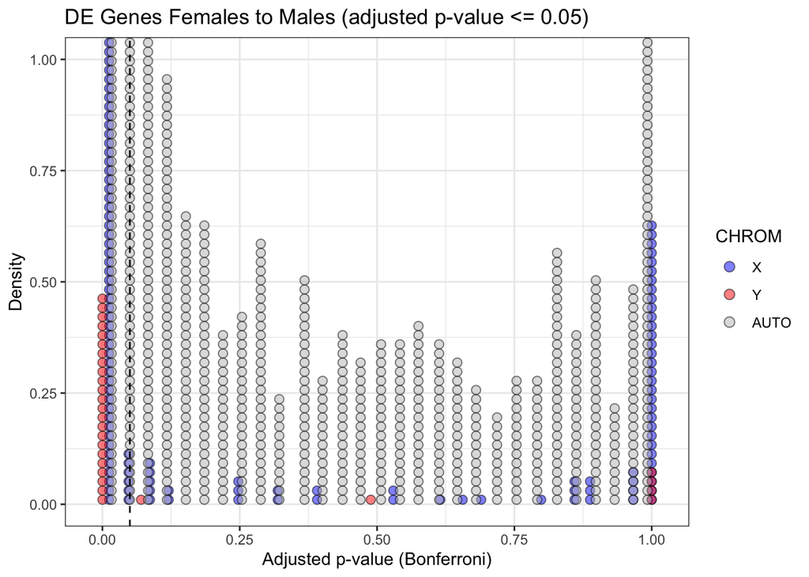

```
## Uploading data to Enrichr... Done.
##   Querying KEGG_2019_Mouse... Done.
## Parsing results... Done.
## Uploading data to Enrichr... Done.
##   Querying KEGG_2019_Mouse... Done.
## Parsing results... Done.
```

```r
    # Examine the primary variable of interest to see if we've solved our issue
    # Before:
    p <- DESeq2::plotPCA(rld, intgroup =pri_var) +
      guides(color=guide_legend(title=pri_var))
    plot(p)
    # After
    p <- DESeq2::plotPCA(rld_final, intgroup = pri_var, ntop = 500) +
      guides(color=guide_legend(title=pri_var))
    plot(p)
    rld <- rld_final
  }
}
```

```r
################################################################################
###### Manual Annotation Opportunity: Take Note of FINAL_FORMULA ###############
################################################################################

################################################################################
# Move back to beginning of for loop and investigate additional batch factors ##
################################################################################

# Find variables associated with PCs
pc_cor_df <- cor_PC_1_4(rld = rld, ntop = 20000, intgroups = names(colData(rld))) %>%
  filter(Adjusted_R_Sq > 0.15) %>%
  arrange(PC)
# Examine Variables of interest for Pcs 1 and 2
pc_cor_df %>%
  filter(PC %in% c(1:4))
```

```
## # A tibble: 4 x 3
##      PC Adjusted_R_Sq Condition
##   <int>         <dbl> <fct>
## 1     2         0.598 animal.registration.cagenumber
## 2     3         0.205 r_260_280
## 3     3         0.187 r_260_230
## 4     3         0.176 calculated.variables.deathtime_after_fed
```

```r
# Visualize variables in PC's 1 and 2
voi <- pc_cor_df %>%
  filter(PC %in% c(1,2)) %>%
  select(Condition) %>% unlist() %>% as.character %>% unique()
# Plot the top variables associated with PCs 1 or 2
for( v in voi){
  # Quick investigation of variables
  #v <- 'RIN'
  title_parts <- pc_cor_df %>%
    filter(Condition == v)
  title <- paste0(title_parts$Condition,'\nPC = ',
                  title_parts$PC,'; R2 = ',
                  round(title_parts$Adjusted_R_Sq,3))
  p <- DESeq2::plotPCA(rld, intgroup =v, ntop = 20000) +
    ggtitle(title)
  plot(p)
}
```

[output not shown]

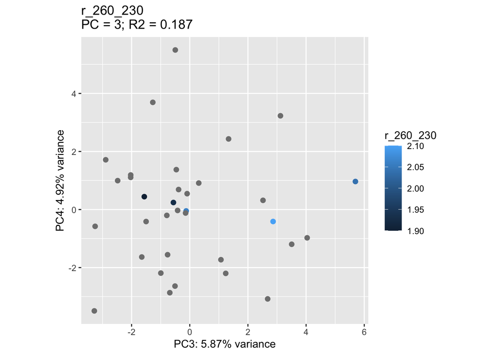

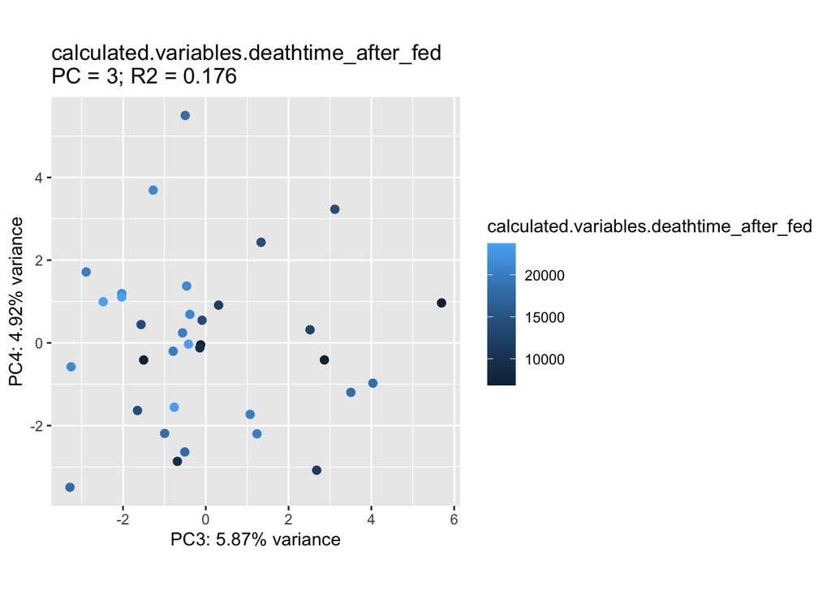

```r
# To examine PC's 3 and 4
if(T){
  # Visualize variables in PC's 3 - 4
  voi34 <- pc_cor_df %>%
    filter(PC %in% c(3:4)) %>%
    select(Condition) %>% unlist() %>% as.character %>% unique()

  # Prepare the data for PC3 and PC4 visualization
  pca <- prcomp(t(assay(rld)), scale. = F)
  df_plot <- pca$x %>% as.data.frame()
  df_plot$sample_key <- row.names(df_plot)
  df_plot <- df_plot %>%
    left_join(y = col_data, by = 'sample_key')
  percentVar <- pca$sdev^2/sum(pca$sdev^2)
  # Plot the top variables associated with PCs 1 or 2
  for( v in voi34){
    # Quick investigation of variables
    title_parts <- pc_cor_df %>%
      filter(Condition == v)
    title <- paste0(title_parts$Condition,'\nPC = ',
                    title_parts$PC,'; R2 = ',
                    round(title_parts$Adjusted_R_Sq,3))
    p <- df_plot %>%
      ggplot(aes(x = PC3, y = PC4, color = !!as.symbol(v))) +
      geom_point(size = 2) +
      coord_equal() +
      xlab(paste0('PC3: ',round(percentVar[3]*100,2),'% variance')) +
      ylab(paste0('PC4: ',round(percentVar[4]*100,2),'% variance')) +
      ggtitle(title)
    plot(p)
  }
}
```

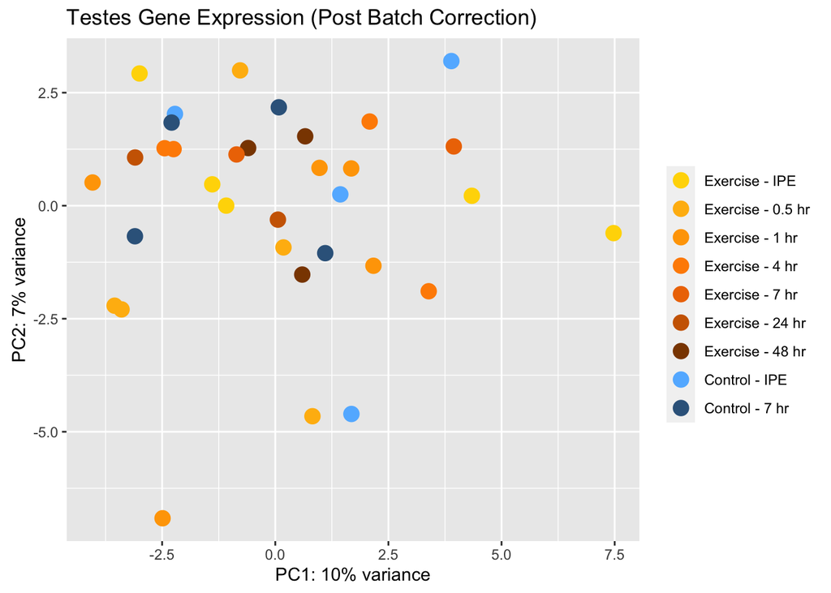

```r
# Plot PCA with corrected counts
mypar()
pcaData <- DESeq2::plotPCA(rld,
                           intgroup=c(pri_var, 'sample_key','animal.key.anirandgroup',
                                      'animal.registration.sex','animal.registration.cagenumber','calculated.variables.deathtime_after_fed'),
                           returnData=TRUE, ntop = 20000)
percentVar <- round(100 * attr(pcaData, 'percentVar'))
# Examine the PCA annotated with variables of interest
pcaData %>%
  mutate(sample_key = as.character(sample_key)) %>%
  mutate(sample_misid_suspect = ifelse(sample_key %in% MIS_SUS, sample_key, '')) %>%
  ggplot(aes(PC1, PC2, color=animal.key.anirandgroup)) +
  geom_point(size=4) +
  #geom_label_repel(aes(label=!!as.symbol(pri_var)),hjust=0, vjust=0) +
  xlab(paste0('PC1: ',percentVar[1],'% variance')) +
  ylab(paste0('PC2: ',percentVar[2],'% variance')) +
  coord_fixed() +
  ggtitle(paste0(TISSUE,' Gene Expression (Post Batch Correction)')) +
  guides(color=guide_legend(title='animal.key.anirandgroup')) +
  scale_color_manual(values=ec_colors) +
  theme(legend.title=element_blank())
```

## Outlier Detection (By Sample)

```r
################################################################################
#####     Outlier Detection (By Sample)     ####################################
################################################################################

# outlier strategy is adapted from Florian Privé (https://www.r-bloggers.com/detecting-outlier-samples-in-pca/)
pca <- prcomp(t(assay(rld)), scale. = F)
PC <- pca$x %>% as.data.frame()
PC$sample_key <- row.names(pca$x)
percentVar <- pca$sdev^2/sum(pca$sdev^2)
```

#### Variance-explained plot: explained variance for PCs

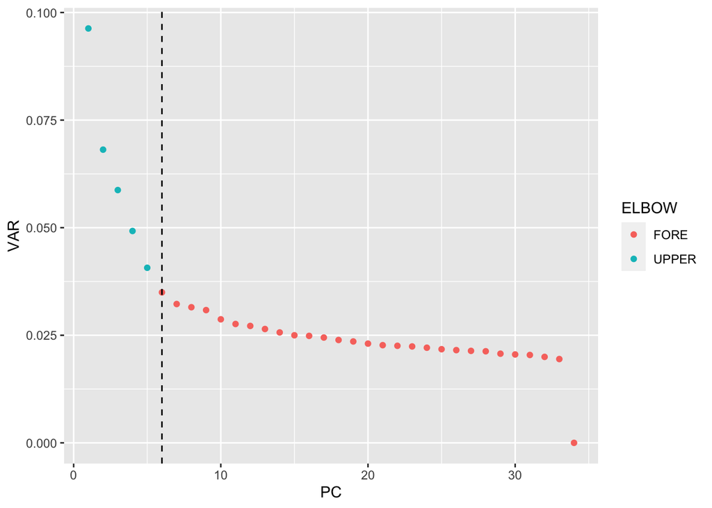

```r
# This iterates through PCs and identifies
df_plot <- data.frame(PC = seq_along(pca$sdev^2/sum(pca$sdev^2)),
                      VAR = pca$sdev^2/sum(pca$sdev^2)) %>%
  mutate(ELBOW = ifelse(PC < elbow_finder(PC,VAR)[1], 'UPPER', 'FORE'))
p <- df_plot %>%
  ggplot(aes(PC,VAR, color = ELBOW)) +
  geom_point() +
  geom_vline(xintercept = elbow_finder(df_plot$PC,df_plot$VAR)[1], linetype='dashed')
plot(p)
```

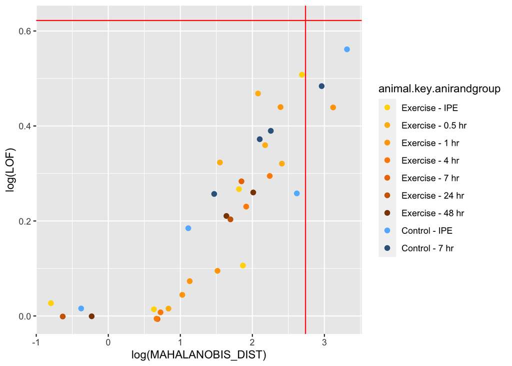

```r
PC_meta <- t(pca$x) %>%
  as_tibble() %>%
  mutate(PC = seq_along(pca$sdev^2/sum(pca$sdev^2))) %>%
  mutate(VAR = pca$sdev^2/sum(pca$sdev^2)) %>%
  mutate(ELBOW = ifelse(PC < elbow_finder(PC,VAR)[1], 'UPPER', 'FORE')) %>%
  filter(ELBOW == 'UPPER') %>%
  mutate(PC = as.character(sprintf('PC%d',PC))) %>%
  filter(PC %in% c('PC1','PC2','PC3','PC4'))
# Reset the pca object
pca <- prcomp(t(assay(rld)), scale. = F,
              rank. = elbow_finder(df_plot$PC,df_plot$VAR)[1] - 1)

# SUbset the PC dataframe to only include PCs above the elbow of PC importance
# We can also detect the distance from the median in units of standard deviation (SD_DIST); use median() instead of mean() and mad() instead of sd() because they are more robust estimators in outlier context.
# Tukey considered data > 6 standard deviations as outliers
# #Instead of using the infinite distance, Mahalanobis distance is a multivariate distance based on all variables (PCs here) at once. We use a robust version of this distance, which is implemented in packages {robust} and {robustbase} (Gnanadesikan and Kettenring 1972, Yohai and Zamar (1988), Maronna and Zamar (2002), Todorov, Filzmoser, and others (2009)) and that is reexported in {bigutilsr}.
#This new criterion provides similar results for this data. These robust Mahalanobis distances are approximately Chi-square distributed, which enables deriving p-values of outlierness.
#Local Outlier Factor (LOF)
#LOF statistic (Breunig et al. 2000) has been cited more than 4000 times. Instead of computing a distance from the center, it uses some local density of points. We make use of the fast K nearest neighbours implementation of R package {nabor} (Elseberg et al. 2012) to implement this statistic efficiently in {bigutilsr}.
#To solve the problem of skewness, the medcouple (mc) has been introduced (Hubert and Vandervieren 2008) and is implemented in robustbase::adjboxStats().
#Tukey’s rule uses a fixed coefficient (1.5) that does not account for multiple testing, which means that for large samples, you will almost always get some outliers if using 1.5.
#To solve these two issues, we implemented tukey_mc_up() that accounts both for skewness and multiple testing by default.

# Collect Standard Deviations
pca$sd <- apply(pca$x, 2, function(x) abs(x - median(x)) / mad(x))
join_meta <- PC_meta[,c('PC','VAR')]
names(join_meta) <- c('SD_DIST_PC','PC_VAR')

PC <- PC %>%
  select(
    c(sprintf('PC%d',1:(elbow_finder(df_plot$PC,df_plot$VAR)[1]-1)),'sample_key')) %>%
  mutate(sample_n = seq_along(PC1)) %>%
  mutate(SD_DIST = apply(pca$x, 2, function(x) abs(x - median(x)) / mad(x)) %>%
           apply(1, max)) %>%
  mutate(SD_DIST_PC = colnames(pca$sd)[apply(pca$sd,1,which.max)]) %>%
  mutate(TUKEY_OUTLIER = ifelse(SD_DIST > 6, 'Outlier', 'Normal')) %>%
  mutate(MAHALANOBIS_DIST = dist_ogk(pca$x)) %>%
  # Bonferroni correction
  mutate(MAHALANOBIS_FDR = pchisq(MAHALANOBIS_DIST, df = elbow_finder(df_plot$PC,df_plot$VAR)[1], lower.tail = FALSE)*length(MAHALANOBIS_DIST)) %>%
  mutate(MAHALANOBIS_OUTLIER = ifelse(MAHALANOBIS_FDR <= 0.05,
                                      'Outlier', 'Normal')) %>%
  mutate(LOF = LOF(pca$x, log = F)) %>%
  left_join(y = col_data, by = 'sample_key') %>%
  left_join(y = join_meta, by = 'SD_DIST_PC') %>%
  arrange(desc(SD_DIST))

# Plot 2 distances (MAHALANOBIS & Local Outlier Factor) on opposing axises and apply Tukey's rule for outlier detection
p <- PC %>%
  mutate(PC_LABEL = ifelse(log(LOF) > tukey_mc_up(log(PC$LOF)) |
                             log(MAHALANOBIS_DIST) > tukey_mc_up(log(PC$MAHALANOBIS_DIST)), SD_DIST_PC, '')) %>%
  ggplot(aes(x = log(MAHALANOBIS_DIST), y = log(LOF), color = animal.key.anirandgroup)) +
  geom_point(size = 2) +
  scale_color_manual(values=ec_colors) +
  geom_vline(xintercept = tukey_mc_up(log(PC$MAHALANOBIS_DIST)), color = 'red') +
  geom_hline(yintercept = tukey_mc_up(log(PC$LOF)),  color = 'red')
plot(p)
```

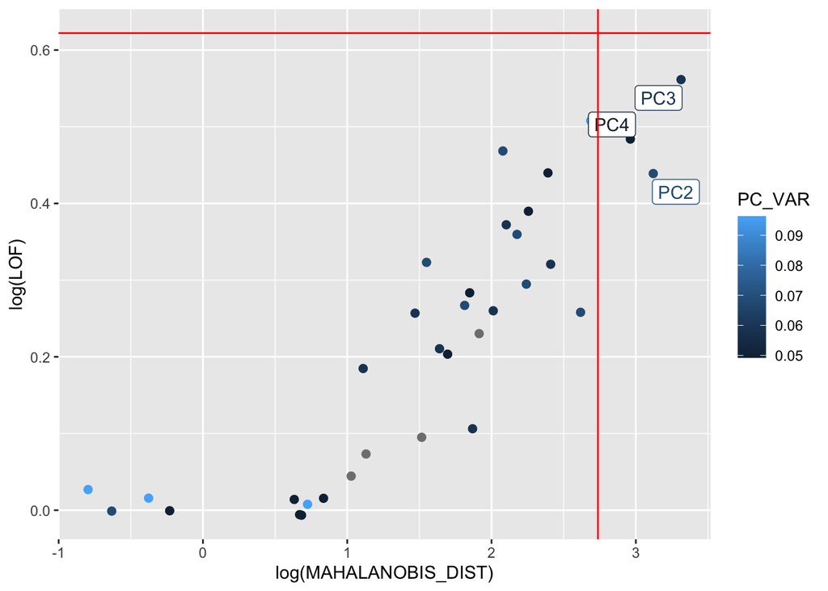

```r
# Examine the variance from of the PC that is associated with the outlier
p <- PC %>%
  mutate(PC_LABEL = ifelse(log(LOF) > tukey_mc_up(log(PC$LOF)) |
                             log(MAHALANOBIS_DIST) > tukey_mc_up(log(PC$MAHALANOBIS_DIST)), SD_DIST_PC, '')) %>%
  ggplot(aes(x = log(MAHALANOBIS_DIST), y = log(LOF), color = PC_VAR)) +
  geom_point(size = 2) +
  geom_label_repel(aes(label=PC_LABEL)) +
  #geom_label_repel(aes(label=sample_key)) +
  geom_vline(xintercept = tukey_mc_up(log(PC$MAHALANOBIS_DIST)), color = 'red') +
  geom_hline(yintercept = tukey_mc_up(log(PC$LOF)),  color = 'red')
plot(p)
```

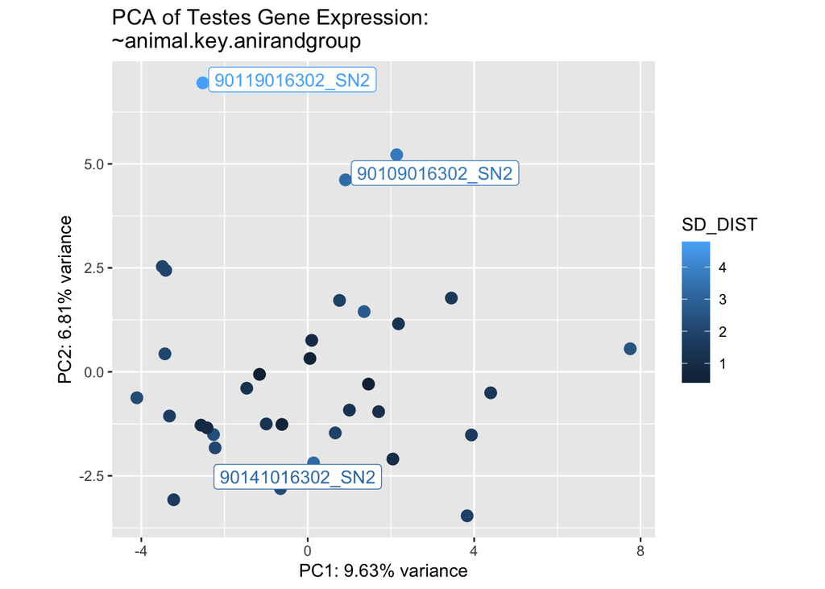

```r
# Examine a PCA plot of points
p <- PC %>%
  mutate(OUTLIER = ifelse(log(LOF) > tukey_mc_up(log(PC$LOF)) |
                             log(MAHALANOBIS_DIST) > tukey_mc_up(log(PC$MAHALANOBIS_DIST)), sample_key, '')) %>%
  ggplot(aes(x = PC1, y = PC2, color = SD_DIST)) +
  geom_point(size = 3) +
  coord_equal() +
  geom_label_repel(aes(label=OUTLIER)) +
  xlab(paste0('PC1: ',round(percentVar[1]*100,2),'% variance')) +
  ylab(paste0('PC2: ',round(percentVar[2]*100,2),'% variance')) +
  ggtitle(paste0('PCA of ',TISSUE,' Gene Expression:\n',FINAL_FORMULA))
plot(p)
```

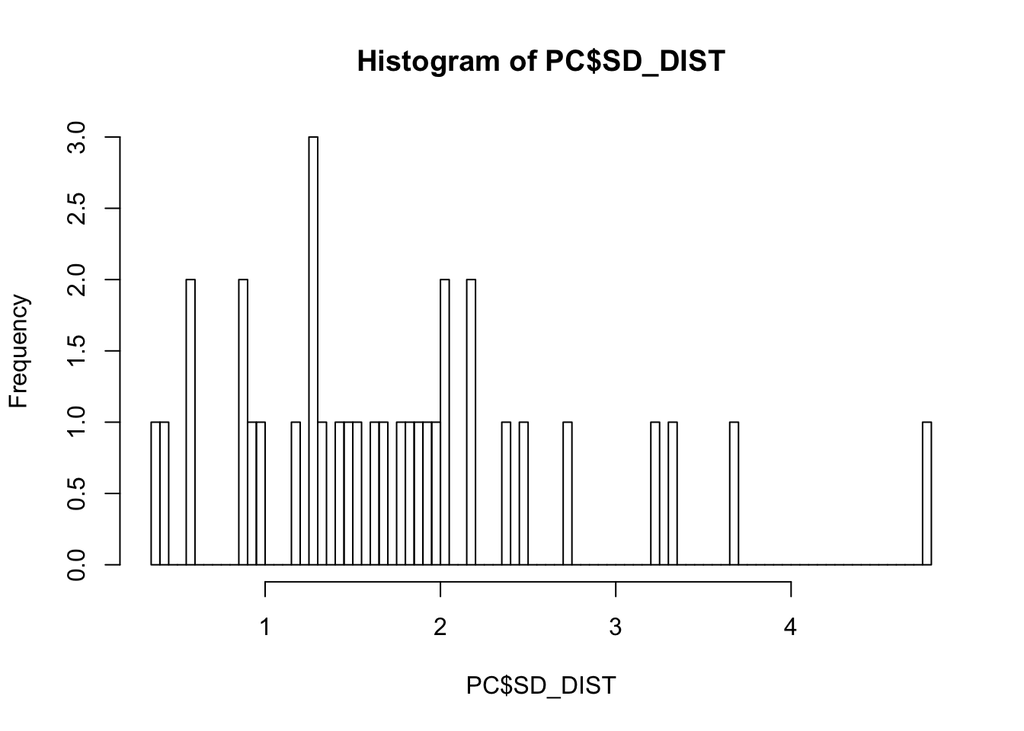

```r
hist(PC$SD_DIST, breaks = 78)
hist(PC$SD_DIST, breaks = 78)
```

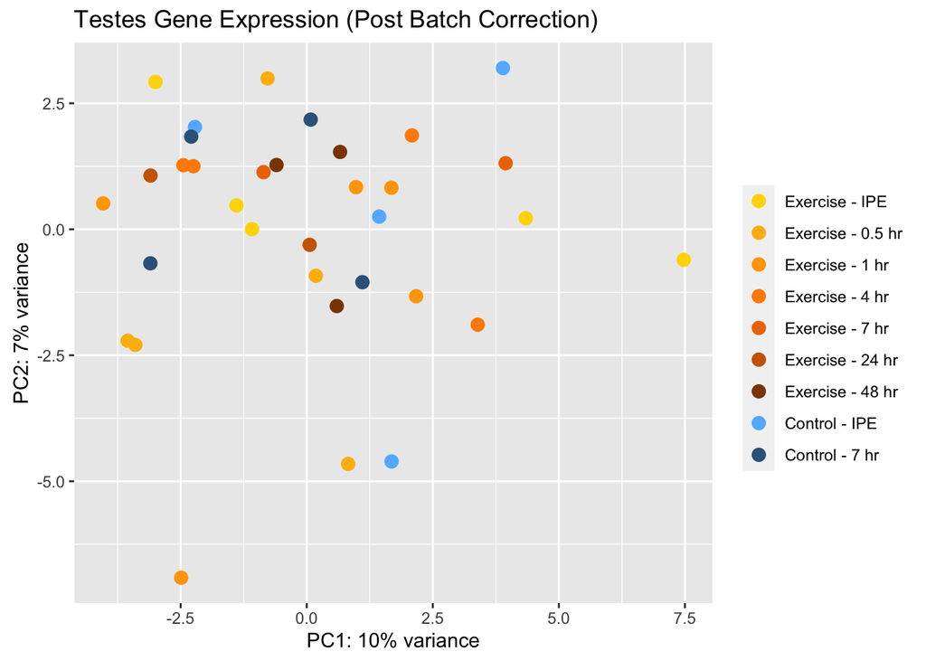

```r
################################################################################
###### Manual Annotation Opportunity: Fill in OUTLIER variable #################
################################################################################
# Note: If Samples Labled as Outliers are in Acute exercise groups, then they likely do not meet our criteria for outliers.

# In case you need to make last minute changes
if(TISSUE %in% c('Brown Adipose')){
  # Filter Samples (meta)
  tod_cols <- col_data %>%
    filter(Tissue == TISSUE) %>%
    filter(sample_key %!in% OUTLIERS) %>%
    filter(!is.na(animal.registration.sex))
  rownames(tod_cols) <- tod_cols$sample_key
  # Collect samples without NA values in TOD
nona_sams <- tod_cols %>%
  filter(!is.na(specimen.collection.t_death_hour)) %>%
  filter(!is.na(animal.registration.sex)) %>%
  select(sample_key) %>% unlist() %>% as.character()
# Collect tissue specific counts
tod_counts <- count_data[,nona_sams]
#### Sanity Check: Ensure that the metadata rownames are identical to count matrix column names
all(rownames(tod_cols) == colnames(tod_counts))
# Create a design formula and load counts and supporting annotation into an S4 object (DESeq infrastructure)
design = formula(paste0('~ ',pri_var)) # Primary variable needs to be last.
dds <- DESeqDataSetFromMatrix(countData = tod_counts,
                                    colData = tod_cols,
                                    design = design)
dds <- dds[rowSums(counts(dds))/ncol(dds) >= 1,]
dds <- estimateSizeFactors(dds)
rld <- DESeq2::vst(dds, blind = F)
# The batch effect can only be removed with limma
# https://support.bioconductor.org/p/76099/ (See Michael Love's Comment)
assay(rld) <- limma::removeBatchEffect(assay(rld), rld[[pri_var]])
}

# Plot PCA with corrected counts
mypar()
pcaData <- DESeq2::plotPCA(rld,
                           intgroup=c(pri_var, 'sample_key','animal.key.anirandgroup',
                                      'animal.registration.sex'),
                           returnData=TRUE, ntop = 20000)
percentVar <- round(100 * attr(pcaData, 'percentVar'))
# Examine the PCA annotated with variables of interest
pcaData %>%
  mutate(sample_key = as.character(sample_key)) %>%
  mutate(sample_misid_suspect = ifelse(sample_key %in% MIS_SUS, sample_key, '')) %>%
  ggplot(aes(PC1, PC2, color=animal.key.anirandgroup)) +
  geom_point(size=3) +
  #geom_label_repel(aes(label=!!as.symbol(pri_var)),hjust=0, vjust=0) +
  xlab(paste0('PC1: ',percentVar[1],'% variance')) +
  ylab(paste0('PC2: ',percentVar[2],'% variance')) +
  coord_fixed() +
  ggtitle(paste0(TISSUE,' Gene Expression (Post Batch Correction)')) +
  guides(color=guide_legend(title='animal.key.anirandgroup')) +
  scale_color_manual(values=ec_colors) +
  theme(legend.title=element_blank())
```

```r
################################################################################
################ Additional Code Notes #########################################
################################################################################


# # TODO: Generate a decision tree for which Var-Specific Strategy to utilize
# # Strategy Symbol Key:
# # Remove - Rm
# # Median center - Mc
# # Model - Mo
# # Sex Genes - Sg
# # Autosomal Genes - Au
# # DE Genes (Sex) - DEg
# # All Genes - Ag
#
# # Collect Samples from dichotomous groups
# L1_samples <- col_data %>%
#   filter(Tissue == TISSUE) %>%
#   filter(!!as.symbol(pri_var) == levels(col_data[[pri_var]])[1]) %>%
#   dplyr::select(sample_key) %>% unlist() %>% as.character()
# L2_samples <- col_data %>%
#   filter(Tissue == TISSUE) %>%
#   filter(!!as.symbol(pri_var) == levels(col_data[[pri_var]])[2]) %>%
#   dplyr::select(sample_key) %>% unlist() %>% as.character()
# SIG_genes <- res_vp %>%
#   filter(SIG == 'SIG') %>%
#   dplyr::select(ENSEMBL_RAT) %>% unlist() %>% as.character()
# NS_genes <- res_vp %>%
#   filter(SIG == 'NS') %>%
#   dplyr::select(ENSEMBL_RAT) %>% unlist() %>% as.character()
# # Select the counts
# L1SIG_counts <- assay(rld_final)[SIG_genes, L1_samples]
# L2SIG_counts <- assay(rld_final[SIG_genes, L2_samples])
# L1NS_counts <- assay(rld_final[NS_genes, L1_samples])
# L2NS_counts <- assay(rld_final[NS_genes, L2_samples])
#
#
# if(VAR_STGY == 'MC_DEg'){
#   # Median Center Significant Genes
#   # Collects median of each row, then subtracts by row medians
#   L1_medians <- apply(L1SIG_counts,1,median)
#   L1SIG_counts <- L1SIG_counts - L1_medians
#   L2_medians <- apply(L2SIG_counts,1,median)
#   L2SIG_counts <- L2SIG_counts - L2_medians
#   SIG_counts <- cbind(L1SIG_counts, L2SIG_counts)
#
#   # Non-Significant Genes
#   NS_counts <- cbind(L1NS_counts, L2NS_counts)
#   MC_DEg_counts <- rbind(SIG_counts, NS_counts)
#   MC_DEg_counts <- MC_DEg_counts[, colnames(assay(rld_final))]
#   assay(rld_final) <- MC_DEg_counts
# }else if(VAR_STGY == 'MC_Ag'){
#   # Median Center Significant Genes
#   # Collects median of each row, then subtracts by row medians
#   M_medians <- apply(MSIG_counts,1,median)
#   MSIG_counts <- MSIG_counts - M_medians
#   F_medians <- apply(FSIG_counts,1,median)
#   FSIG_counts <- FSIG_counts - F_medians
#   SIG_counts <- cbind(MSIG_counts, FSIG_counts)
#
#   # Non-Significant Genes
#   M_medians <- apply(MNS_counts,1,median)
#   MNS_counts <- MNS_counts - M_medians
#   F_medians <- apply(FNS_counts,1,median)
#   FNS_counts <- FNS_counts - F_medians
#   NS_counts <- cbind(MNS_counts, FNS_counts)
#   MC_Ag_counts <- rbind(SIG_counts, NS_counts)
#   MC_Ag_counts <- MC_Ag_counts[, colnames(assay(rld_final))]
#   #rld <- rld
#   assay(rld_final) <- MC_Ag_counts
# }


# # Fit the LDA
# lda.fit = train(design, data=train_df, method='lda',
#                 trControl = control)
#
# lda.fit
# summary(lda.fit)
#
# pred_sex = predict(lda.fit, test_df)
# table(pred_sex, test_df[[mis_id_var]])
#
# pred.accuracy = round(mean(pred_sex == test_df[[mis_id_var]])*100,2)
# pred.accuracy



# Examine counts of top gene
# assay(rld)['ENSRNOG00000050000',MIS_SUS] %>% as.numeric()
# t <- assay(rld)['ENSRNOG00000050000',] %>% as.data.frame()
# t$sample <- row.names(t)
# t %>%
#   filter(sample %!in% MIS_SUS) %>% as.numeric()
#
# t <- counts(dds, normalized = TRUE) %>% as.data.frame()
# t$ENSEMBL_RAT <- row.names(t)
# t <- t %>%
#   filter(ENSEMBL_RAT == 'ENSRNOG00000050000') %>%
#   t() %>% as.data.frame()
# t$SAMPLE <- row.names(t)
# t <- t[-79,]
# b1 <- (col_data %>% filter(animal.key.batch == '1'))$sample_key %>% as.character()
# t <- t %>%
#   mutate(COHORT = ifelse(SAMPLE %in% MIS_SUS, 'SUS', 'NORM')) %>%
#   mutate(BATCH = ifelse(SAMPLE %in% b1, '1', '2'))
# t <- t %>% as_tibble()
# t <- t %>% mutate(COUNT = ENSRNOG00000050000 %>% unlist() %>% as.character() %>% as.numeric())
#
# t %>%
#   ggplot(aes(x = BATCH, y = COUNT, color = COHORT)) +
#   geom_point()
#plotCounts(dds, gene='ENSRNOG00000050000', intgroup='animal.key.batch')
```